**CS4132 Data Analytics**

# Counter Strike: Global Offensive; Player Analysis by Huang Yuebin

Important Note: Please keep your report concise and relevant (i.e. show only relevant steps and visualizations used to answer your research questions).

# Table of Content (with relevant hyperlinks to sections)

Motivation & Background

Summary of Research Questions & Results

Dataset

Methodology

Data Acquisition

Data Cleaning

EDA

Results and Conclusions

Recommendations or Further Works

References

# Motivation and Background

Give an overview of the project, motivation, background and goals.

Counter Strike: Global Offensive, CSGO for short, has been the bread and butter of Esports for 9 years. CSGO is a 5v5 tactical First-Person-Shooter. Teams compete against each other in different CSGO maps, where one team plays as the Terrorists and the other as Counter-Terrorists, each with different game objectives. Teams buy weapons based off of their economy, which is affected by their personal performance as well as round wins.

I have been playing CSGO for nearly 5 years and despite the times where I "swear I will never play this trash game ever again", I still find myself coming back to this game that I love.

I love the game mostly for 2 reasons:

1. Its competitive
   - There is little places where RNG affects the outcome of the match. If you win, it is because you played better, made better decisions, it is rarely due to luck that a round goes one way rather than the other.
2. Its complex
   - The rounds are varied. No two rounds are played out the same way as the other, leading to many unique outcomes despite having the same, equal and fair start across all matches, where teams start out with the same health and economy.
   - The skill ceiling is very high, almost limitless. Players have to improve on both their micro (aiming, movement) and macro (gamesense, strategies) skills to be able to compete at the highest level.

So, I want to explore on the trends of professional players, the patterns in the games by using Data Analytics to gain a deeper insight, albeit one that is still quite shallow as compared to real CSGO analysts VOD-reviewing the gameplay itself and studying the teams, players, and their decisions frame by frame.

The data in this project will be via web-scraping of the HLTV website. HLTV is the main platform to gain information of professional matches in CSGO, and is free for everyone to view all the content, which is good for web-scraping. (Sort of like LiveScore in football.)

# Summary of Research Questions & Results

Repeat your research questions in a numbered list. After each research question, clearly state the answer/conclusion you determined. Do not give details or justifications yet — just the answer

1. What makes a good entry fragger?
   - Is a good entry fragger one that just wins more opening duels? What if these opening kills are not impactful?
   - Does entry fragging mean they sacrifice their ability to get multikills for the greater good of the team?
2. How does pressure and experience affect performance?
   - Different people react differently when faced with pressure. In a LAN match or a Major event, the conditions are very different as compared to playing an online match.
   - I want to compare how players fare in these conditions, if it makes a difference at all based on their experience.
3. How does age impact a player's performance, and their role in a team?
   - It is a common stigma that older players are "slower to react" than younger players, and that the lifespan of esports players are very short.
   - So does age differences truly make a difference in game? Or are the roles of the players spread evenly across the ages?
4. How does different sides affect a role's flashes and pistol rounds?
   - T and CT sides have different objectives and different advantages to win the round. I want to see how the sides affects their utility usage in flashes, as well as in pistol rounds.
5. How does a player's role affect their performance?
   - A player could be an AWPer, or a Rifler, which affects their playstyles due to the nature of the weapons, being that the AWP is a one shot bodyshot kill, allowing them to get easier kills, but have a longer drawout time and lower firerate than rifles. How do these factors affect their performance in game?

# Dataset

Numbered list of dataset (with downloadable links) and a brief but clear description of each dataset used. Draw reference to the numbering when describing methodology (data cleaning and analysis).

1. https://www.hltv.org/

   Web-scraping will be done on this site to gather more data on various statistics, such as player rating, player Kill-Death Ratio (K/D), team round win percent (RW%) and many other statistics. See the Jupyter Notebook HLTV Web Scraper.ipynb for source code.

# Methodology

There is only one source of data and it is from HLTV. HLTV holds the monopoly in CSGO esports data, and has information on 10 years of player data. Firstly I will web scrape data off from the website from the respective pages as well as individual player pages (for more descriptive data). Due to the website having a rate limit as well as including some anomalies in table entries, I will split the web scraping of individual players into chunks by saving web scraped data periodically while scraping to reduce the time taken to scrape all of the data, so that when an error occurs or a rate limit is reached, some of the data is already saved and I do not need to start scraping from square one again.

After scraping the data, I will import it and combine the many CSV files into their own dataframes. Afterwards I will clean the data by accounting for NaN values as well as the website's version of NaN values saved as other strings, such as dashes ('-'), while dropping columns that are irrelevant and repetitive.

At the end, EDA will be performed on each group of dataframes, followed by improving upon graphs in the EDA inside Results and Conclusion.

## Data Acquisition

Display the data which will be used in the project.

The data should be saved in .xlsx or .csv format to be submitted with the project. If webscraping has been done to obtain your data, save your webscraping code in another jupyter notebook as appendix to be submitted separately from the report.

Import and display each dataset in a dataframe.

For each dataset, give a brief overview of the data it contains, and explain the meaning of columns that are relevant to the project.

```python
import os
import pandas as pd
import numpy as np
WEB_SCRAPED = "Web Scraped"
CAREER = f"{WEB_SCRAPED}/players_career"
INDIVIDUAL = f"{WEB_SCRAPED}/players_individual"
OVERVIEW = f"{WEB_SCRAPED}/players_overview"
```

This dataframe contains the ratings of each player across different types of matches. Each row is a player. The index is "name" referring to each player's in-game-name (aka IGN). "hltv_id" is not really relevant here, but is useful to access the player's individual webpage on hltv.org.

Online refers to matches played online, where players experience ping differences due to the latency of information being transmitted from a player's inputs at their computers to the CSGO server itself. Often, players play in the comfort of their own homes or in a bootcamp organised by their respective organisations, meant to simulate the environment of a LAN event.

A LAN event, or a Local-Area-Network event, in this case refers to CSGO matches played on the same LAN, resulting to negligible ping/latency, so that the match played is more fair. The pressure is also higher at LAN events/matches, since most requires teams to qualify through playing multiple qualifier matches. At LAN events, there is usually an audience too, which only makes it more nerve wracking for some people.

Majors are only for the cream of the crop, where they are only held once per year, with the top teams competing against each other on the biggest stage CSGO has to offer, with a massive live audience in a stadium, an average of almost 300 thousand viewers online, and prize pools worth a million dollars. Needless to say this is the most important event in CSGO, and major winners are highly regarded by the players.

- "X-rating" refers to the the rating of the player in that type of matches played. For example, "all-rating" means rating across all maps played across all events, whether it be online, LAN, or in a Major.
- "X-maps" refers to the number of maps played by the player within that type of match. For example, "majors-maps" refers to the number of maps played in CSGO Major events.

```python
career = pd.DataFrame()
for csv in os.scandir(CAREER):
    if not csv.is_file():
        continue
    career_offset = pd.read_csv(csv)
    career = pd.concat([career, career_offset])
career.set_index("name", inplace=True)
print(career.info())
career.head()
```

```
<class 'pandas.core.frame.DataFrame'>
Index: 823 entries, ZywOo to BL1TZ
Data columns (total 9 columns):
 #   Column         Non-Null Count  Dtype
---  ------         --------------  -----
 0   hltv_id        823 non-null    int64
 1   all-rating     823 non-null    float64
 2   online-rating  823 non-null    float64
 3   lan-rating     823 non-null    object
 4   majors-rating  823 non-null    object
 5   all-maps       823 non-null    int64
 6   online-maps    823 non-null    int64
 7   lan-maps       823 non-null    int64
 8   majors-maps    823 non-null    int64
dtypes: float64(2), int64(5), object(2)
memory usage: 64.3+ KB
None
```

| name | hltv_id | all-rating | online-rating | lan-rating | majors-rating | all-maps | online-maps | lan-maps | majors-maps |
| --- | --- | --- | --- | --- | --- | --- | --- | --- | --- |
| ZywOo | 11893 | 1.27 | 1.28 | 1.25 | 1.16 | 1043 | 630 | 413 | 41 |
| s1mple | 7998 | 1.25 | 1.24 | 1.26 | 1.21 | 1589 | 850 | 739 | 92 |
| sh1ro | 16920 | 1.22 | 1.23 | 1.19 | 1.12 | 886 | 733 | 153 | 15 |
| deko | 20113 | 1.21 | 1.21 | 1.14 | - | 442 | 435 | 7 | -1 |
| saffee | 18835 | 1.20 | 1.22 | 1.1 | 1.05 | 404 | 321 | 83 | 10 |

This dataframe contains the specific information of each individual player.

Opening kills are the first kills in a round, which is arguably the most important one as it sets the tempo for the rest of the round. A 5v4 in favor of your team is a huge bonus from a 5v5, since the enemies need to play much better in order to make up for the lower manpower.

- "o_total_k" refers to total opening kills a player has gotten.
- "o_total_d" refers to the total opening deaths a player has gotten.
- "o_ratio" is the ratio of total opening kills to deaths.
- "o_rating" refers to the rating of how good the player is at getting opening kills, based on a metric designed by HLTV
- "o_win%" refers to the chances of the player's team winning after they got their opening kill.
- "o_won_rounds" refers to the percentage of rounds the team won where the player has gotten a first kill.

Each round starts off as a 5v5, so a player can kill anywhere between 0 and 5 players (inclusive) each round. There are no revives.

- "rounds_Xk" means number of rounds the player had X number of kills.

Every round players buy weapons to increase their firepower and their chances of winning the round. Each weapon can be classified under either Rifle, Sniper, SMG (sub-machine gun), Pistols, Grenades or Other.

- "X_k" refers to number of kills with X weapon. For example, "rifle_k" means number of kills this player has using the rifle.

```python
players_individual = pd.DataFrame()
for csv in os.scandir(INDIVIDUAL):
    if not csv.is_file():
        continue
    individual_offset = pd.read_csv(csv)
    players_individual = pd.concat([players_individual, individual_offset])
players_individual.set_index("name", inplace=True)
print(players_individual.info())
players_individual.head()
```

```
<class 'pandas.core.frame.DataFrame'>
Index: 820 entries, ZywOo to BL1TZ
Data columns (total 19 columns):
 #   Column        Non-Null Count  Dtype
---  ------        --------------  -----
 0   hltv_id       820 non-null    int64
 1   o_total_k     820 non-null    int64
 2   o_total_d     820 non-null    int64
 3   o_ratio       820 non-null    float64
 4   o_rating      820 non-null    float64
 5   o_win%        820 non-null    object
 6   o_won_rounds  820 non-null    object
 7   rounds_0k     820 non-null    int64
 8   rounds_1k     820 non-null    int64
 9   rounds_2k     820 non-null    int64
 10  rounds_3k     820 non-null    int64
 11  rounds_4k     820 non-null    int64
 12  rounds_5k     820 non-null    int64
 13  rifle_k       820 non-null    int64
 14  sniper_k      820 non-null    int64
 15  smg_k         820 non-null    int64
 16  pistol_k      820 non-null    int64
 17  grenade_k     820 non-null    int64
 18  other_k       820 non-null    int64
dtypes: float64(2), int64(15), object(2)
memory usage: 128.1+ KB
None
```

| name | hltv_id | o_total_k | o_total_d | o_ratio | o_rating | o_win% | o_won_rounds | rounds_0k | rounds_1k | rounds_2k | rounds_3k | rounds_4k | rounds_5k | rifle_k | sniper_k | smg_k | pistol_k | grenade_k | other_k |
| --- | --- | --- | --- | --- | --- | --- | --- | --- | --- | --- | --- | --- | --- | --- | --- | --- | --- | --- | --- |
| ZywOo | 11893 | 4236 | 2633 | 1.61 | 1.28 | 73.1% | 21.3% | 12884 | 8392 | 4179 | 1510 | 376 | 71 | 8513 | 8737 | 1298 | 4328 | 267 | 50 |
| s1mple | 7998 | 6084 | 3789 | 1.61 | 1.24 | 75.2% | 20.8% | 19176 | 13254 | 6701 | 2284 | 507 | 64 | 14830 | 13627 | 916 | 6107 | 205 | 256 |
| sh1ro | 16920 | 2705 | 1383 | 1.96 | 1.15 | 77.0% | 16.2% | 11501 | 7416 | 3208 | 1075 | 221 | 30 | 3791 | 10580 | 550 | 3008 | 175 | 70 |
| deko | 20113 | 1369 | 781 | 1.75 | 1.13 | 76.2% | 16.5% | 5615 | 3922 | 1700 | 565 | 124 | 8 | 2963 | 4703 | 205 | 1584 | 96 | 43 |
| saffee | 18835 | 1309 | 892 | 1.47 | 1.14 | 76.1% | 17.3% | 5213 | 3288 | 1548 | 524 | 114 | 14 | 2545 | 4412 | 264 | 1209 | 52 | 28 |

This dataframe contains the more general information of each player.

- "age" is a measure of their real life age.
- "team" refers to the team that they represent in matches currently. (Some have no team as they have either retired or moved on to other jobs.)
- "rating" is a measure of how good a player is based on a metric designed by HLTV, taking into account of the following statistics.
- "DPR" is short for Deaths Per Round, it refers to the deaths per round of the player.
- "KAST" is short for Kill/Assist/Survived/Traded, which measures the percentage of rounds where a player has done any of the 4 aforementioned things. You could say this measures a player's consistent impact throughout the match.
- "impact" measures how impactful the player is when getting opening kills, multi-kills, and clutches.
- "ADR" is short for Average Damager per Round a measure of how much damage a player deals every round.
- "KPR" is short for Kills Per Round the number of kills a player gets per round.

```python
players_overview = pd.DataFrame()
for csv in os.scandir(OVERVIEW):
    if not csv.is_file():
        continue
    overview_offset = pd.read_csv(csv)
    players_overview = pd.concat([players_overview, overview_offset])
players_overview.set_index("name", inplace=True)
print(players_overview.info())
players_overview.head()
```

```
<class 'pandas.core.frame.DataFrame'>
Index: 819 entries, ZywOo to hades
Data columns (total 9 columns):
 #   Column   Non-Null Count  Dtype
---  ------   --------------  -----
 0   hltv_id  819 non-null    int64
 1   age      819 non-null    object
 2   team     819 non-null    object
 3   rating   819 non-null    float64
 4   DPR      819 non-null    float64
 5   KAST     819 non-null    object
 6   impact   819 non-null    float64
 7   ADR      819 non-null    float64
 8   KPR      819 non-null    float64
dtypes: float64(5), int64(1), object(3)
memory usage: 64.0+ KB
None
```

| name | hltv_id | age | team | rating | DPR | KAST | impact | ADR | KPR |
| --- | --- | --- | --- | --- | --- | --- | --- | --- | --- |
| ZywOo | 11893 | 21 years | Vitality | 1.32 | 0.61 | 75.0% | 1.44 | 87.9 | 0.84 |
| s1mple | 7998 | 24 years | Natus Vincere | 1.25 | 0.64 | 74.1% | 1.36 | 86.3 | 0.85 |
| sh1ro | 16920 | 21 years | Cloud9 | 1.26 | 0.53 | 76.3% | 1.21 | 78.6 | 0.77 |
| deko | 20113 | 21 years | 1WIN | 1.23 | 0.58 | 74.4% | 1.20 | 80.3 | 0.80 |
| saffee | 18835 | 27 years | FURIA | 1.22 | 0.61 | 73.4% | 1.24 | 80.2 | 0.79 |

The following 3 dataframes contain information on flashes. A flashbang grenade is a utility that can be bought every round, and it is very powerful. If a player much better than you is fighting a 1v1 against you, a well placed flashbang will win you the round by blinding the opponent long enough for you to take your time to hit the headshot.

Each dataframe correspond to a different set of data, one from flashes thrown as Counter-Terrorists, one from Terrorists, and one for both combined.

- "Maps" refers to total maps played by the player.
- "Rounds" refer to total rounds played by the player.
- "Thrown" means the number of flashes thrown per round on average.
- "Blinded" refers to how long the player themselves were blinded for every round.
- "Opp Flashed" refers to how long the opponents are blinded for by this player every round.
- "Diff" is the difference between the time the opponents were flashed and the time the player themselves were blinded for per round.
- "FA" refers to flash assists per round. A flash assist happens when an opponent blinded by this player was killed while affected by the flash.
- "Success" refers to flash success, how many opponents were flashed for every flashbang thrown.

```python
flashes_CT = pd.read_csv(f"{WEB_SCRAPED}/players_flashes_CT.csv").set_index("Player")
flashes_T = pd.read_csv(f"{WEB_SCRAPED}/players_flashes_T.csv").set_index("Player")
flashes_overall = pd.read_csv(f"{WEB_SCRAPED}/players_flashes_overall.csv").set_index("Player")
flashes = flashes_CT.merge(flashes_T, left_index=True, right_index=True)
flashes
```

| Player | Maps_x | Rounds_x | Thrown_x | Blinded_x | Opp Flashed_x | Diff_x | FA_x | Success_x | Maps_y | Rounds_y | Thrown_y | Blinded_y | Opp Flashed_y | Diff_y | FA_y | Success_y |
| --- | --- | --- | --- | --- | --- | --- | --- | --- | --- | --- | --- | --- | --- | --- | --- | --- |
| 0i | 390 | 5221 | 0.40 | 1.64s | 0.90s | -0.74 | 0.03 | 0.62 | 390 | 5017 | 0.73 | 1.05s | 1.45s | 0.40 | 0.04 | 0.59 |
| 1962 | 551 | 7132 | 0.43 | 1.96s | 1.11s | -0.85 | 0.03 | 0.70 | 551 | 7208 | 0.64 | 1.23s | 1.43s | 0.20 | 0.04 | 0.65 |
| 1uke | 425 | 5631 | 0.46 | 1.56s | 1.18s | -0.38 | 0.03 | 0.71 | 425 | 5387 | 0.79 | 1.19s | 1.78s | 0.59 | 0.07 | 0.65 |
| 7oX1C | 354 | 4685 | 0.27 | 1.31s | 0.69s | -0.63 | 0.03 | 0.69 | 354 | 4679 | 0.93 | 0.85s | 2.12s | 1.28 | 0.06 | 0.65 |
| ADDICT | 314 | 4115 | 0.30 | 1.37s | 0.89s | -0.48 | 0.04 | 0.86 | 314 | 4043 | 0.56 | 0.92s | 1.21s | 0.29 | 0.05 | 0.65 |
| ... | ... | ... | ... | ... | ... | ... | ... | ... | ... | ... | ... | ... | ... | ... | ... | ... |
| zewsy | 457 | 5893 | 0.77 | 1.44s | 1.98s | 0.54 | 0.08 | 0.70 | 457 | 5665 | 1.06 | 1.03s | 2.17s | 1.14 | 0.05 | 0.58 |
| zhokiNg | 843 | 11053 | 0.37 | 1.40s | 0.95s | -0.44 | 0.03 | 0.72 | 843 | 10782 | 0.52 | 1.09s | 1.01s | -0.08 | 0.02 | 0.56 |
| zorte | 777 | 10245 | 0.68 | 2.04s | 1.72s | -0.32 | 0.06 | 0.71 | 777 | 10537 | 1.07 | 1.37s | 2.57s | 1.20 | 0.08 | 0.71 |
| zqkS | 630 | 8148 | 0.52 | 2.02s | 1.41s | -0.62 | 0.06 | 0.74 | 630 | 8128 | 1.03 | 1.23s | 2.45s | 1.22 | 0.09 | 0.69 |
| ztr | 428 | 5701 | 0.54 | 1.66s | 1.46s | -0.20 | 0.05 | 0.74 | 428 | 5740 | 0.97 | 1.29s | 2.28s | 0.98 | 0.08 | 0.68 |

835 rows × 16 columns

```python
flashes_CT = pd.read_csv(f"{WEB_SCRAPED}/players_flashes_CT.csv").set_index("Player")
flashes_T = pd.read_csv(f"{WEB_SCRAPED}/players_flashes_T.csv").set_index("Player")
flashes_overall = pd.read_csv(f"{WEB_SCRAPED}/players_flashes_overall.csv").set_index("Player")
flashes_overall.head()
```

| Player | Maps | Rounds | Thrown | Blinded | Opp Flashed | Diff | FA | Success |
| --- | --- | --- | --- | --- | --- | --- | --- | --- |
| SANJI | 739 | 19790 | 0.60 | 1.61s | 1.66s | 0.05 | 0.04 | 0.83 |
| Rainwaker | 1163 | 31366 | 0.48 | 1.34s | 1.35s | 0.01 | 0.05 | 0.81 |
| Polt | 534 | 14139 | 0.45 | 1.14s | 1.23s | 0.08 | 0.03 | 0.81 |
| Duplicate | 816 | 21810 | 0.56 | 1.65s | 1.58s | -0.07 | 0.05 | 0.81 |
| Maluk3 | 1007 | 26041 | 0.67 | 1.62s | 1.94s | 0.31 | 0.10 | 0.81 |

As mentioned previously, opening kills are crucial to the round, and more or less determines the pace of the round afterwards. The following 3 dataframes contain information on opening kills.

Each dataframe correspond to a different set of data, one from opening kills as Counter-Terrorists, one from Terrorists, and one for both combined.

- "Maps" refers to total maps played by the player.
- "Rounds" refers to total rounds played by the player.
- "KPR" refers to opening kills per round.
- "DPR" refers to opening deaths per round.
- "Attempts" refers to percentage of rounds where the player is involved in an opening kill or opening death. (% of rounds where a player "entried")
- "Success" refers to the success rate of players when they do take the opening duel.
- "Rating" is a measure of how good a player is at getting opening kills, which is similar to entry-fragging.

```python
opening_CT = pd.read_csv(f"{WEB_SCRAPED}/players_opening_CT.csv").set_index("Player")
opening_T = pd.read_csv(f"{WEB_SCRAPED}/players_opening_T.csv").set_index("Player")
opening_overall = pd.read_csv(f"{WEB_SCRAPED}/players_opening_overall.csv").set_index("Player")
opening_overall.head()
```

| Player | Maps | Rounds | KPR | DPR | Attempts | Success | Rating |
| --- | --- | --- | --- | --- | --- | --- | --- |
| chelleos | 575 | 14838 | 0.18 | 0.14 | 31.8% | 55.6% | 1.32 |
| ZywOo | 1043 | 27412 | 0.15 | 0.10 | 25.1% | 61.7% | 1.28 |
| arT | 1011 | 26280 | 0.17 | 0.17 | 34.7% | 50.4% | 1.25 |
| s1mple | 1589 | 41986 | 0.14 | 0.09 | 23.5% | 61.6% | 1.24 |
| xsepower | 1298 | 34858 | 0.14 | 0.09 | 23.4% | 61.8% | 1.24 |

The following 3 dataframes contain information on pistol rounds. Pistol rounds are to maps like opening kills are to rounds. Winning pistol rounds essentially secure teams for 2 more round wins, due to having a better economy after winning, resulting in higher chances of winning the following rounds where enemies are forced to save

- "Teams" is not relevant here, and will be removed in the data cleaning process. It is a result of modularising the web scraping code to fit different pages with similar layouts.
- "Maps" refers to total maps played by the player.
- "K/D Diff" refers to the numbers of kills - number of deaths.
- "K/D" refers to the kill-death ratio.
- "Rating1.0" refers to a rating of how good a player is at pistol rounds.

```python
pistol_CT = pd.read_csv(f"{WEB_SCRAPED}/players_pistol_CT.csv").set_index("Player")
pistol_T = pd.read_csv(f"{WEB_SCRAPED}/players_pistol_T.csv").set_index("Player")
pistol_overall = pd.read_csv(f"{WEB_SCRAPED}/players_pistol_overall.csv").set_index("Player")
pistol_overall.head()
```

| Player | Teams | Maps | K/D Diff | K/D | Rating1.0 |
| --- | --- | --- | --- | --- | --- |
| ZywOo | NaN | 1043 | 588 | 1.41 | 1.39 |
| NK4Y | NaN | 480 | 189 | 1.28 | 1.31 |
| deko | NaN | 442 | 219 | 1.38 | 1.30 |
| XigN | NaN | 742 | 329 | 1.33 | 1.28 |
| TenZ | NaN | 401 | 128 | 1.22 | 1.27 |

This dataframe contains the general player information across the years, from 2012 till 2022. There are many NaN entries since not many players are consistently at the top or continue playing CSGO professionally for so long.

(This dataset will not be used due to the large amount of NaN values, as well as due to the inconsistent Rating metric, in which HLTV changed in 2017)

```python
years = pd.read_csv(f"{WEB_SCRAPED}/players_years.csv", index_col=[0], header=[0,1])
print(years.info())
years.head()
```

```
<class 'pandas.core.frame.DataFrame'>
Index: 1264 entries, GeT_RiGhT to DDias
Data columns (total 55 columns):
 #   Column            Non-Null Count  Dtype
---  ------            --------------  -----
 0   (2012, Maps)      55 non-null     float64
 1   (2012, Rounds)    55 non-null     float64
 2   (2012, K-D Diff)  55 non-null     float64
 3   (2012, K/D)       55 non-null     float64
 4   (2012, Rating)    55 non-null     float64
 5   (2013, Maps)      82 non-null     float64
 6   (2013, Rounds)    82 non-null     float64
 7   (2013, K-D Diff)  82 non-null     float64
 8   (2013, K/D)       82 non-null     float64
 9   (2013, Rating)    82 non-null     float64
```

[output cut: 48 more lines]

| Player | 2012 Maps | 2012 Rounds | 2012 K-D Diff | 2012 K/D | 2012 Rating | 2013 Maps | 2013 Rounds | 2013 K-D Diff | 2013 K/D | 2013 Rating | ... | 2021 Maps | 2021 Rounds | 2021 K-D Diff | 2021 K/D | 2021 Rating | 2022 Maps | 2022 Rounds | 2022 K-D Diff | 2022 K/D | 2022 Rating |
| --- | --- | --- | --- | --- | --- | --- | --- | --- | --- | --- | --- | --- | --- | --- | --- | --- | --- | --- | --- | --- | --- |
| GeT_RiGhT | 64.0 | 1461.0 | 625.0 | 1.82 | 1.47 | 273.0 | 6697.0 | 2137.0 | 1.58 | 1.33 | ... | NaN | NaN | NaN | NaN | NaN | NaN | NaN | NaN | NaN | NaN |
| f0rest | 64.0 | 1461.0 | 549.0 | 1.72 | 1.38 | 264.0 | 6464.0 | 1749.0 | 1.46 | 1.28 | ... | 229.0 | 6254.0 | 409.0 | 1.1 | 1.1 | NaN | NaN | NaN | NaN | NaN |
| ScreaM | 26.0 | 630.0 | 138.0 | 1.31 | 1.30 | 207.0 | 5301.0 | 864.0 | 1.27 | 1.17 | ... | NaN | NaN | NaN | NaN | NaN | NaN | NaN | NaN | NaN | NaN |
| Xizt | 64.0 | 1461.0 | 407.0 | 1.49 | 1.26 | 273.0 | 6692.0 | 987.0 | 1.25 | 1.12 | ... | NaN | NaN | NaN | NaN | NaN | NaN | NaN | NaN | NaN | NaN |
| Troubley | 33.0 | 815.0 | 191.0 | 1.39 | 1.26 | 90.0 | 2294.0 | 270.0 | 1.17 | 1.14 | ... | NaN | NaN | NaN | NaN | NaN | NaN | NaN | NaN | NaN | NaN |

5 rows × 55 columns

## Data Cleaning

For data cleaning, be clear in which dataset (or variables) are used, what has been done for missing data, how was merging performed, explanation of data transformation (if any). If data is calculated or summarized from the raw dataset, explain the rationale and steps clearly.

Most of the "data cleaning" is done in the web-scraping process so that when the data is saved to a CSV file it is legible and does not cause confusion

Here data cleaning is done on the dataframe "career" to replace null-placeholders leftover from web-scraping to proper null-values and numerical values. '-' is replaced with np.nan since the players are unable to have a rating for events where they have never participated in. -1 is replaced with 0 since -1 was used as a placeholder null in web-scraping, and if they have not played any majors or LANs, they would have played 0 maps in those events.

```python
career.replace('-', np.nan, inplace=True)
career.replace(-1, 0, inplace=True)
career
```

| name | hltv_id | all-rating | online-rating | lan-rating | majors-rating | all-maps | online-maps | lan-maps | majors-maps |
| --- | --- | --- | --- | --- | --- | --- | --- | --- | --- |
| ZywOo | 11893 | 1.27 | 1.28 | 1.25 | 1.16 | 1043 | 630 | 413 | 41 |
| s1mple | 7998 | 1.25 | 1.24 | 1.26 | 1.21 | 1589 | 850 | 739 | 92 |
| sh1ro | 16920 | 1.22 | 1.23 | 1.19 | 1.12 | 886 | 733 | 153 | 15 |
| deko | 20113 | 1.21 | 1.21 | 1.14 | NaN | 442 | 435 | 7 | 0 |
| saffee | 18835 | 1.20 | 1.22 | 1.1 | 1.05 | 404 | 321 | 83 | 10 |
| ... | ... | ... | ... | ... | ... | ... | ... | ... | ... |
| lollipop21k | 13980 | 1.09 | 1.09 | 1.06 | NaN | 1211 | 1168 | 43 | 0 |
| EliGE | 8738 | 1.09 | 1.10 | 1.07 | 1.07 | 1621 | 866 | 755 | 60 |
| dennyslaw | 13466 | 1.09 | 1.08 | 1.15 | NaN | 1207 | 1168 | 39 | 0 |
| hades | 16848 | 1.09 | 1.11 | 1.02 | 0.90 | 608 | 474 | 134 | 14 |
| BL1TZ | 12715 | 1.09 | 1.10 | 0.98 | NaN | 740 | 644 | 96 | 0 |

823 rows × 9 columns

Dropping irrelevant columns, as "Teams" is all null-values due to the website saving the team information as an image of the team logo. Team information is also available on the players_overview dataframe, so it is not necessary here.

```python
pistol_overall.drop(columns=["Teams"], inplace=True)
pistol_T.drop(columns=["Teams"], inplace=True)
pistol_CT.drop(columns=["Teams"], inplace=True)


pistol_CT = pistol_CT.loc[~pistol_CT.index.duplicated()]
pistol_T = pistol_T.loc[~pistol_T.index.duplicated()]
pistol_overall = pistol_overall.loc[~pistol_overall.index.duplicated()]
pistol = pd.concat([pistol_CT, pistol_T, pistol_overall], axis=1, keys="CT T Both".split())
pistol.head()
```

| Player | CT Maps | CT K/D Diff | CT K/D | CT Rating1.0 | T Maps | T K/D Diff | T K/D | T Rating1.0 | Both Maps | Both K/D Diff | Both K/D | Both Rating1.0 |
| --- | --- | --- | --- | --- | --- | --- | --- | --- | --- | --- | --- | --- |
| ZywOo | 1043 | 373 | 1.55 | 1.47 | 1043 | 215 | 1.29 | 1.32 | 1043 | 588 | 1.41 | 1.39 |
| meyern | 466 | 142 | 1.47 | 1.41 | 466 | 5 | 1.01 | 1.03 | 466 | 147 | 1.23 | 1.22 |
| deko | 442 | 152 | 1.55 | 1.41 | 442 | 67 | 1.22 | 1.19 | 442 | 219 | 1.38 | 1.30 |
| b4rtiN | 547 | 184 | 1.52 | 1.40 | 547 | 33 | 1.08 | 1.10 | 547 | 217 | 1.29 | 1.25 |
| desi | 430 | 140 | 1.49 | 1.39 | 430 | 6 | 1.02 | 1.09 | 430 | 146 | 1.24 | 1.24 |

Due to some data entries into ratings as dashes or some other non-numeric value in the CSV, when loading the CSV Pandas interprets it as a string column. So after replacing the strings with appropriate values, I could convert the columns to int/float

```python
career['lan-rating'] = career['lan-rating'].astype(float)
career['majors-rating'] = career['majors-rating'].astype(float)
print(career.info())
career
```

```
<class 'pandas.core.frame.DataFrame'>
Index: 823 entries, ZywOo to BL1TZ
Data columns (total 9 columns):
 #   Column         Non-Null Count  Dtype
---  ------         --------------  -----
 0   hltv_id        823 non-null    int64
 1   all-rating     823 non-null    float64
 2   online-rating  823 non-null    float64
 3   lan-rating     822 non-null    float64
 4   majors-rating  299 non-null    float64
 5   all-maps       823 non-null    int64
 6   online-maps    823 non-null    int64
 7   lan-maps       823 non-null    int64
 8   majors-maps    823 non-null    int64
dtypes: float64(4), int64(5)
memory usage: 64.3+ KB
None
```

| name | hltv_id | all-rating | online-rating | lan-rating | majors-rating | all-maps | online-maps | lan-maps | majors-maps |
| --- | --- | --- | --- | --- | --- | --- | --- | --- | --- |
| ZywOo | 11893 | 1.27 | 1.28 | 1.25 | 1.16 | 1043 | 630 | 413 | 41 |
| s1mple | 7998 | 1.25 | 1.24 | 1.26 | 1.21 | 1589 | 850 | 739 | 92 |
| sh1ro | 16920 | 1.22 | 1.23 | 1.19 | 1.12 | 886 | 733 | 153 | 15 |
| deko | 20113 | 1.21 | 1.21 | 1.14 | NaN | 442 | 435 | 7 | 0 |
| saffee | 18835 | 1.20 | 1.22 | 1.10 | 1.05 | 404 | 321 | 83 | 10 |
| ... | ... | ... | ... | ... | ... | ... | ... | ... | ... |
| lollipop21k | 13980 | 1.09 | 1.09 | 1.06 | NaN | 1211 | 1168 | 43 | 0 |
| EliGE | 8738 | 1.09 | 1.10 | 1.07 | 1.07 | 1621 | 866 | 755 | 60 |
| dennyslaw | 13466 | 1.09 | 1.08 | 1.15 | NaN | 1207 | 1168 | 39 | 0 |
| hades | 16848 | 1.09 | 1.11 | 1.02 | 0.90 | 608 | 474 | 134 | 14 |
| BL1TZ | 12715 | 1.09 | 1.10 | 0.98 | NaN | 740 | 644 | 96 | 0 |

823 rows × 9 columns

Data saved as a percentage on the webpage is formatted with a percentage sign, so we need to change it to a decimal value that can be used in calculations for all such data.

```python
players_individual["o_win%"] = players_individual["o_win%"].str.strip("%").astype(float) / 100.0
players_individual["o_won_rounds"] = players_individual["o_won_rounds"].str.strip("%").astype(float) / 100.0
players_individual
```

| name | hltv_id | o_total_k | o_total_d | o_ratio | o_rating | o_win% | o_won_rounds | rounds_0k | rounds_1k | rounds_2k | rounds_3k | rounds_4k | rounds_5k | rifle_k | sniper_k | smg_k | pistol_k | grenade_k | other_k |
| --- | --- | --- | --- | --- | --- | --- | --- | --- | --- | --- | --- | --- | --- | --- | --- | --- | --- | --- | --- |
| ZywOo | 11893 | 4236 | 2633 | 1.61 | 1.28 | 0.731 | 0.213 | 12884 | 8392 | 4179 | 1510 | 376 | 71 | 8513 | 8737 | 1298 | 4328 | 267 | 50 |
| s1mple | 7998 | 6084 | 3789 | 1.61 | 1.24 | 0.752 | 0.208 | 19176 | 13254 | 6701 | 2284 | 507 | 64 | 14830 | 13627 | 916 | 6107 | 205 | 256 |
| sh1ro | 16920 | 2705 | 1383 | 1.96 | 1.15 | 0.770 | 0.162 | 11501 | 7416 | 3208 | 1075 | 221 | 30 | 3791 | 10580 | 550 | 3008 | 175 | 70 |
| deko | 20113 | 1369 | 781 | 1.75 | 1.13 | 0.762 | 0.165 | 5615 | 3922 | 1700 | 565 | 124 | 8 | 2963 | 4703 | 205 | 1584 | 96 | 43 |
| saffee | 18835 | 1309 | 892 | 1.47 | 1.14 | 0.761 | 0.173 | 5213 | 3288 | 1548 | 524 | 114 | 14 | 2545 | 4412 | 264 | 1209 | 52 | 28 |
| ... | ... | ... | ... | ... | ... | ... | ... | ... | ... | ... | ... | ... | ... | ... | ... | ... | ... | ... | ... |
| lollipop21k | 13980 | 3185 | 2586 | 1.23 | 1.03 | 0.716 | 0.138 | 16289 | 10072 | 4237 | 1413 | 321 | 43 | 18375 | 262 | 1647 | 3785 | 237 | 29 |
| EliGE | 8738 | 5532 | 5171 | 1.07 | 1.11 | 0.738 | 0.180 | 21401 | 12953 | 5829 | 1849 | 418 | 55 | 24618 | 230 | 1781 | 5156 | 307 | 86 |
| dennyslaw | 13466 | 4044 | 2831 | 1.43 | 1.14 | 0.750 | 0.181 | 16601 | 9902 | 4369 | 1284 | 256 | 31 | 7750 | 11817 | 601 | 3316 | 201 | 62 |
| hades | 16848 | 1884 | 1206 | 1.56 | 1.12 | 0.758 | 0.171 | 8212 | 5132 | 2161 | 643 | 106 | 7 | 3323 | 6464 | 111 | 1900 | 57 | 22 |
| BL1TZ | 12715 | 2308 | 1863 | 1.24 | 1.11 | 0.764 | 0.179 | 9679 | 5799 | 2591 | 776 | 173 | 17 | 6484 | 4570 | 576 | 2367 | 98 | 28 |

820 rows × 19 columns

"age" has unnecessary text included ("years" is not needed) so we need to extract the integer value out of the data, and change the column datatype to int.

```python
players_overview["age"] = players_overview["age"].str.split().str[0].astype(int)
players_overview["KAST"] = players_overview["KAST"].str.strip("%").astype(float) / 100.0
players_overview
```

| name | hltv_id | age | team | rating | DPR | KAST | impact | ADR | KPR |
| --- | --- | --- | --- | --- | --- | --- | --- | --- | --- |
| ZywOo | 11893 | 21 | Vitality | 1.32 | 0.61 | 0.750 | 1.44 | 87.9 | 0.84 |
| s1mple | 7998 | 24 | Natus Vincere | 1.25 | 0.64 | 0.741 | 1.36 | 86.3 | 0.85 |
| sh1ro | 16920 | 21 | Cloud9 | 1.26 | 0.53 | 0.763 | 1.21 | 78.6 | 0.77 |
| deko | 20113 | 21 | 1WIN | 1.23 | 0.58 | 0.744 | 1.20 | 80.3 | 0.80 |
| saffee | 18835 | 27 | FURIA | 1.22 | 0.61 | 0.734 | 1.24 | 80.2 | 0.79 |
| ... | ... | ... | ... | ... | ... | ... | ... | ... | ... |
| ScreaM | 7390 | 28 | No team | 1.09 | 0.66 | 0.711 | 1.11 | 79.1 | 0.74 |
| dennyslaw | 13466 | 22 | ex-SKADE | 1.12 | 0.64 | 0.709 | 1.14 | 74.8 | 0.73 |
| EliGE | 8738 | 25 | Liquid | 1.09 | 0.68 | 0.713 | 1.25 | 83.7 | 0.76 |
| floppy | 12713 | 22 | Complexity | 1.15 | 0.66 | 0.732 | 1.14 | 81.3 | 0.74 |
| hades | 16848 | 22 | Finest | 1.11 | 0.62 | 0.707 | 1.11 | 73.8 | 0.73 |

819 rows × 9 columns

"Blinded" and "Opp Flashed" is a measure of time in seconds, but we do not need the trailing "s" in the value so that we can save the value as a float. So we can reformat it and convert the datatype to the correct one.

```python
for flashes in [flashes_CT, flashes_overall, flashes_T]:
    flashes["Blinded"] = flashes["Blinded"].str.strip("s").astype(float)
    flashes["Opp Flashed"] = flashes["Opp Flashed"].str.strip("s").astype(float)
flashes_overall


flashes_CT = flashes_CT.loc[~flashes_CT.index.duplicated()]
flashes_T = flashes_T.loc[~flashes_T.index.duplicated()]
flashes_overall = flashes_overall.loc[~flashes_overall.index.duplicated()]
flashes = pd.concat([flashes_CT, flashes_T, flashes_overall], axis=1, keys="CT T Both".split())
flashes.head()
```

| Player | CT Maps | CT Rounds | CT Thrown | CT Blinded | CT Opp Flashed | CT Diff | CT FA | CT Success | T Maps | T Rounds | T ... | T FA | T Success | Both Maps | Both Rounds | Both Thrown | Both Blinded | Both Opp Flashed | Both Diff | Both FA | Both Success |
| --- | --- | --- | --- | --- | --- | --- | --- | --- | --- | --- | --- | --- | --- | --- | --- | --- | --- | --- | --- | --- | --- |
| kzy | 572 | 7589 | 0.58 | 1.64 | 1.94 | 0.30 | 0.09 | 0.92 | 572 | 7354 | ... | 0.11 | 0.73 | 572 | 14943 | 0.78 | 1.39 | 2.24 | 0.85 | 0.10 | 0.80 |
| apEX | 1088 | 14491 | 0.42 | 1.91 | 1.44 | -0.46 | 0.06 | 0.91 | 1088 | 14200 | ... | 0.08 | 0.68 | 1088 | 28691 | 0.57 | 1.60 | 1.59 | -0.01 | 0.07 | 0.76 |
| boX | 1275 | 16917 | 0.50 | 1.84 | 1.59 | -0.25 | 0.05 | 0.91 | 1275 | 17066 | ... | 0.07 | 0.71 | 1275 | 33983 | 0.70 | 1.63 | 1.97 | 0.34 | 0.06 | 0.78 |
| Maluk3 | 1007 | 12994 | 0.44 | 2.00 | 1.47 | -0.54 | 0.08 | 0.91 | 1007 | 13047 | ... | 0.12 | 0.76 | 1007 | 26041 | 0.67 | 1.62 | 1.94 | 0.31 | 0.10 | 0.81 |
| crisby | 613 | 8150 | 0.56 | 1.41 | 1.90 | 0.49 | 0.07 | 0.90 | 613 | 7897 | ... | 0.07 | 0.68 | 613 | 16047 | 0.65 | 1.27 | 1.87 | 0.60 | 0.07 | 0.78 |

5 rows × 24 columns

```python
for opening in [opening_CT, opening_overall, opening_T]:
    opening["Attempts"] = opening["Attempts"].str.strip("%").astype(float) / 100.0
    opening["Success"] = opening["Success"].str.strip("%").astype(float) / 100.0

opening_CT = opening_CT.loc[~opening_CT.index.duplicated()]
opening_T = opening_T.loc[~opening_T.index.duplicated()]
opening_overall = opening_overall.loc[~opening_overall.index.duplicated()]
opening = pd.concat([opening_CT, opening_T, opening_overall], axis=1, keys="CT T Both".split())
opening.head()
```

| Player | CT Maps | CT Rounds | CT KPR | CT DPR | CT Attempts | CT Success | CT Rating | T Maps | T Rounds | T KPR | T ... | T Attempts | T Success | T Rating | Both Maps | Both Rounds | Both KPR | Both DPR | Both Attempts | Both Success | Both Rating |
| --- | --- | --- | --- | --- | --- | --- | --- | --- | --- | --- | --- | --- | --- | --- | --- | --- | --- | --- | --- | --- | --- |
| chelleos | 575 | 7265 | 0.21 | 0.13 | 0.344 | 0.609 | 1.49 | 575 | 7573 | 0.15 | ... | 0.293 | 0.497 | 1.15 | 575 | 14838 | 0.18 | 0.14 | 0.318 | 0.556 | 1.32 |
| ZywOo | 1043 | 13775 | 0.19 | 0.09 | 0.273 | 0.679 | 1.45 | 1043 | 13637 | 0.12 | ... | 0.228 | 0.542 | 1.11 | 1043 | 27412 | 0.15 | 0.10 | 0.251 | 0.617 | 1.28 |
| xsepower | 1298 | 17423 | 0.18 | 0.09 | 0.276 | 0.662 | 1.42 | 1298 | 17435 | 0.11 | ... | 0.191 | 0.555 | 1.06 | 1298 | 34858 | 0.14 | 0.09 | 0.234 | 0.618 | 1.24 |
| mertz | 955 | 12838 | 0.18 | 0.10 | 0.286 | 0.638 | 1.41 | 955 | 12495 | 0.11 | ... | 0.212 | 0.516 | 1.04 | 955 | 25333 | 0.15 | 0.10 | 0.250 | 0.586 | 1.23 |
| s1mple | 1589 | 21025 | 0.18 | 0.09 | 0.267 | 0.664 | 1.40 | 1589 | 20961 | 0.11 | ... | 0.204 | 0.554 | 1.08 | 1589 | 41986 | 0.14 | 0.09 | 0.235 | 0.616 | 1.24 |

5 rows × 21 columns

Combining players_overview and players_individual into one dataframe for easier access to the data.

```python
players = pd.merge(left=players_individual.drop(columns=["hltv_id"]), right=players_overview, left_index=True, right_index=True)
players = players[~players.index.duplicated()]
players
```

| name | o_total_k | o_total_d | o_ratio | o_rating | o_win% | o_won_rounds | rounds_0k | rounds_1k | rounds_2k | rounds_3k | ... | other_k | hltv_id | age | team | rating | DPR | KAST | impact | ADR | KPR |
| --- | --- | --- | --- | --- | --- | --- | --- | --- | --- | --- | --- | --- | --- | --- | --- | --- | --- | --- | --- | --- | --- |
| 0i | 1160 | 1247 | 0.93 | 0.96 | 0.684 | 0.128 | 6886 | 3921 | 1531 | 425 | ... | 23 | 11358 | 26 | Invictus | 1.00 | 0.71 | 0.690 | 0.98 | 73.3 | 0.67 |
| 1962 | 1747 | 1793 | 0.97 | 1.05 | 0.728 | 0.162 | 7982 | 4448 | 1863 | 631 | ... | 16 | 12094 | 26 | Leviatan | 1.07 | 0.71 | 0.696 | 1.14 | 76.7 | 0.71 |
| 1uke | 2247 | 1858 | 1.21 | 1.17 | 0.733 | 0.207 | 8713 | 4715 | 2072 | 569 | ... | 23 | 8724 | 29 | No team | 1.00 | 0.67 | 0.673 | 1.16 | 71.6 | 0.68 |
| ALEX | 3278 | 3941 | 0.83 | 0.99 | 0.731 | 0.151 | 16449 | 8992 | 3803 | 1234 | ... | 54 | 8184 | 26 | fnatic | 0.99 | 0.71 | 0.674 | 1.09 | 76.3 | 0.70 |
| ALLE | 1222 | 1167 | 1.05 | 1.00 | 0.755 | 0.144 | 6743 | 3732 | 1508 | 430 | ... | 24 | 11922 | 25 | Paquetá | 1.06 | 0.67 | 0.708 | 1.05 | 76.8 | 0.68 |
| ... | ... | ... | ... | ... | ... | ... | ... | ... | ... | ... | ... | ... | ... | ... | ... | ... | ... | ... | ... | ... | ... |
| zhokiNg | 4519 | 4348 | 1.04 | 1.15 | 0.748 | 0.195 | 15876 | 9642 | 4298 | 1393 | ... | 33 | 8601 | 28 | YK | 1.06 | 0.71 | 0.727 | 1.28 | 83.8 | 0.75 |
| znajder | 2724 | 2477 | 1.10 | 1.01 | 0.730 | 0.143 | 14114 | 8651 | 3568 | 1042 | ... | 128 | 3847 | 29 | No team | 1.03 | 0.68 | 0.699 | 1.05 | 76.8 | 0.72 |
| zorte | 2665 | 1722 | 1.55 | 1.17 | 0.742 | 0.186 | 10621 | 6395 | 2754 | 830 | ... | 29 | 15662 | 24 | forZe | 1.15 | 0.60 | 0.724 | 1.16 | 74.3 | 0.73 |
| zqkS | 2430 | 1817 | 1.34 | 1.11 | 0.737 | 0.174 | 11100 | 6201 | 2422 | 641 | ... | 71 | 7383 | 30 | Corinthians | 1.00 | 0.62 | 0.704 | 1.04 | 69.5 | 0.66 |
| ztr | 1040 | 1225 | 0.85 | 0.94 | 0.740 | 0.135 | 6393 | 3336 | 1314 | 389 | ... | 36 | 16486 | 19 | Young Ninjas | 0.98 | 0.69 | 0.671 | 0.97 | 71.9 | 0.64 |

817 rows × 27 columns

```python
years.sort_values(by=("2022", "Rating"), ascending=False)
```

| Player | 2012 Maps | 2012 Rounds | 2012 K-D Diff | 2012 K/D | 2012 Rating | 2013 Maps | 2013 Rounds | 2013 K-D Diff | 2013 K/D | 2013 Rating | ... | 2021 Maps | 2021 Rounds | 2021 K-D Diff | 2021 K/D | 2021 Rating | 2022 Maps | 2022 Rounds | 2022 K-D Diff | 2022 K/D | 2022 Rating |
| --- | --- | --- | --- | --- | --- | --- | --- | --- | --- | --- | --- | --- | --- | --- | --- | --- | --- | --- | --- | --- | --- |
| s1mple | NaN | NaN | NaN | NaN | NaN | NaN | NaN | NaN | NaN | NaN | ... | 198.0 | 5277.0 | 1487.0 | 1.47 | 1.35 | 104.0 | 2813.0 | 656.0 | 1.38 | 1.28 |
| sh1ro | NaN | NaN | NaN | NaN | NaN | NaN | NaN | NaN | NaN | NaN | ... | 245.0 | 6458.0 | 1524.0 | 1.45 | 1.24 | 95.0 | 2493.0 | 664.0 | 1.51 | 1.28 |
| XANTARES | NaN | NaN | NaN | NaN | NaN | NaN | NaN | NaN | NaN | NaN | ... | 301.0 | 8057.0 | 889.0 | 1.17 | 1.18 | 185.0 | 5012.0 | 730.0 | 1.22 | 1.27 |
| ZywOo | NaN | NaN | NaN | NaN | NaN | NaN | NaN | NaN | NaN | NaN | ... | 171.0 | 4522.0 | 1005.0 | 1.37 | 1.29 | 118.0 | 3189.0 | 682.0 | 1.36 | 1.26 |
| nqz | NaN | NaN | NaN | NaN | NaN | NaN | NaN | NaN | NaN | NaN | ... | NaN | NaN | NaN | NaN | NaN | 91.0 | 2425.0 | 613.0 | 1.47 | 1.25 |
| ... | ... | ... | ... | ... | ... | ... | ... | ... | ... | ... | ... | ... | ... | ... | ... | ... | ... | ... | ... | ... | ... |
| RIZZZ | NaN | NaN | NaN | NaN | NaN | NaN | NaN | NaN | NaN | NaN | ... | 174.0 | 4690.0 | -332.0 | 0.90 | 0.97 | NaN | NaN | NaN | NaN | NaN |
| jemi | NaN | NaN | NaN | NaN | NaN | NaN | NaN | NaN | NaN | NaN | ... | 203.0 | 5388.0 | -421.0 | 0.88 | 0.94 | NaN | NaN | NaN | NaN | NaN |
| 1eeR | NaN | NaN | NaN | NaN | NaN | NaN | NaN | NaN | NaN | NaN | ... | 144.0 | 3823.0 | -307.0 | 0.88 | 0.92 | NaN | NaN | NaN | NaN | NaN |
| simix | NaN | NaN | NaN | NaN | NaN | NaN | NaN | NaN | NaN | NaN | ... | 156.0 | 4168.0 | -632.0 | 0.78 | 0.87 | NaN | NaN | NaN | NaN | NaN |
| insane | NaN | NaN | NaN | NaN | NaN | NaN | NaN | NaN | NaN | NaN | ... | 162.0 | 4198.0 | -738.0 | 0.76 | 0.85 | NaN | NaN | NaN | NaN | NaN |

1264 rows × 55 columns

Delegating roles to players based on their ratio of rifle kills to sniper kills. In a team, there is generally a dedicated AWPer who uses the sniper to get more kills for the team, with 4 other riflers to support the AWPer.

```python
gun_k = players.loc[:, "rifle_k": "other_k"].sum().sort_values()
rifle_sniper_ratio = gun_k["rifle_k"] / gun_k["sniper_k"]
players["rifle_sniper_ratio"] = players["rifle_k"] / players["sniper_k"]
players["role"] = np.nan
def player_role(row):
    if row["rifle_sniper_ratio"] > rifle_sniper_ratio:
        row["role"] = "Rifler"
    else:
        row["role"] = "Awper"
    return row

players = players.apply(player_role, axis="columns")
players
```

| name | o_total_k | o_total_d | o_ratio | o_rating | o_win% | o_won_rounds | rounds_0k | rounds_1k | rounds_2k | rounds_3k | ... | age | team | rating | DPR | KAST | impact | ADR | KPR | rifle_sniper_ratio | role |
| --- | --- | --- | --- | --- | --- | --- | --- | --- | --- | --- | --- | --- | --- | --- | --- | --- | --- | --- | --- | --- | --- |
| 0i | 1160 | 1247 | 0.93 | 0.96 | 0.684 | 0.128 | 6886 | 3921 | 1531 | 425 | ... | 26 | Invictus | 1.00 | 0.71 | 0.690 | 0.98 | 73.3 | 0.67 | 103.448276 | Rifler |
| 1962 | 1747 | 1793 | 0.97 | 1.05 | 0.728 | 0.162 | 7982 | 4448 | 1863 | 631 | ... | 26 | Leviatan | 1.07 | 0.71 | 0.696 | 1.14 | 76.7 | 0.71 | 64.200000 | Rifler |
| 1uke | 2247 | 1858 | 1.21 | 1.17 | 0.733 | 0.207 | 8713 | 4715 | 2072 | 569 | ... | 29 | No team | 1.00 | 0.67 | 0.673 | 1.16 | 71.6 | 0.68 | 0.224150 | Awper |
| ALEX | 3278 | 3941 | 0.83 | 0.99 | 0.731 | 0.151 | 16449 | 8992 | 3803 | 1234 | ... | 26 | fnatic | 0.99 | 0.71 | 0.674 | 1.09 | 76.3 | 0.70 | 24.417742 | Rifler |
| ALLE | 1222 | 1167 | 1.05 | 1.00 | 0.755 | 0.144 | 6743 | 3732 | 1508 | 430 | ... | 25 | Paquetá | 1.06 | 0.67 | 0.708 | 1.05 | 76.8 | 0.68 | 16.717033 | Rifler |
| ... | ... | ... | ... | ... | ... | ... | ... | ... | ... | ... | ... | ... | ... | ... | ... | ... | ... | ... | ... | ... | ... |
| zhokiNg | 4519 | 4348 | 1.04 | 1.15 | 0.748 | 0.195 | 15876 | 9642 | 4298 | 1393 | ... | 28 | YK | 1.06 | 0.71 | 0.727 | 1.28 | 83.8 | 0.75 | 248.459459 | Rifler |
| znajder | 2724 | 2477 | 1.10 | 1.01 | 0.730 | 0.143 | 14114 | 8651 | 3568 | 1042 | ... | 29 | No team | 1.03 | 0.68 | 0.699 | 1.05 | 76.8 | 0.72 | 7.812427 | Rifler |
| zorte | 2665 | 1722 | 1.55 | 1.17 | 0.742 | 0.186 | 10621 | 6395 | 2754 | 830 | ... | 24 | forZe | 1.15 | 0.60 | 0.724 | 1.16 | 74.3 | 0.73 | 0.570417 | Awper |
| zqkS | 2430 | 1817 | 1.34 | 1.11 | 0.737 | 0.174 | 11100 | 6201 | 2422 | 641 | ... | 30 | Corinthians | 1.00 | 0.62 | 0.704 | 1.04 | 69.5 | 0.66 | 0.403826 | Awper |
| ztr | 1040 | 1225 | 0.85 | 0.94 | 0.740 | 0.135 | 6393 | 3336 | 1314 | 389 | ... | 19 | Young Ninjas | 0.98 | 0.69 | 0.671 | 0.97 | 71.9 | 0.64 | 71.506494 | Rifler |

817 rows × 29 columns

## EDA

For each research questions shortlisted, outline your methodology in answering them. Discuss interesting observations or results discovered.

Please note to only show EDA that's relevant to answering the question at hand. If you have done any data modeling, include in this section.

```python
import matplotlib.pyplot as plt
import seaborn as sns
import joypy
from pywaffle import Waffle
```

### Research Question 1: What makes a good entry fragger?

Entry fraggers are the catalysts to the rounds. They get the round started by making space for the team, going in first before anyone else to gain more information. This role is the most dangerous role in the team, as they are the first contact to the enemies.

Different players have different playstyles, so not every player is cut out to be the entry fragger. However, how do we measure whether it is worth it for X player to entry frag? Their impact on the round is more than just their kills. They contribute by creating space for their teammates, and even their deaths are valuable since the second player can trade their deaths by killing the enemy.

```python
openings = opening_overall.merge(players.loc[:,:"o_won_rounds"], left_index=True, right_index=True)
openings.drop(columns=["o_rating"], inplace=True)
openings
```

|  | Maps | Rounds | KPR | DPR | Attempts | Success | Rating | o_total_k | o_total_d | o_ratio | o_win% | o_won_rounds |
| --- | --- | --- | --- | --- | --- | --- | --- | --- | --- | --- | --- | --- |
| chelleos | 575 | 14838 | 0.18 | 0.14 | 0.318 | 0.556 | 1.32 | 2625 | 2093 | 1.25 | 0.724 | 0.247 |
| ZywOo | 1043 | 27412 | 0.15 | 0.10 | 0.251 | 0.617 | 1.28 | 4236 | 2633 | 1.61 | 0.731 | 0.213 |
| arT | 1011 | 26280 | 0.17 | 0.17 | 0.347 | 0.504 | 1.25 | 4580 | 4507 | 1.02 | 0.737 | 0.239 |
| s1mple | 1589 | 41986 | 0.14 | 0.09 | 0.235 | 0.616 | 1.24 | 6084 | 3789 | 1.61 | 0.752 | 0.208 |
| xsepower | 1298 | 34858 | 0.14 | 0.09 | 0.234 | 0.618 | 1.24 | 5036 | 3110 | 1.62 | 0.750 | 0.207 |
| ... | ... | ... | ... | ... | ... | ... | ... | ... | ... | ... | ... | ... |
| Twista | 380 | 9970 | 0.08 | 0.11 | 0.188 | 0.402 | 0.86 | 753 | 1121 | 0.67 | 0.724 | 0.110 |
| advent | 1116 | 28709 | 0.06 | 0.07 | 0.134 | 0.461 | 0.86 | 1776 | 2080 | 0.85 | 0.745 | 0.084 |
| coolio | 379 | 10205 | 0.06 | 0.07 | 0.133 | 0.460 | 0.85 | 624 | 732 | 0.85 | 0.723 | 0.089 |
| vSa | 385 | 10066 | 0.05 | 0.06 | 0.115 | 0.441 | 0.81 | 511 | 648 | 0.79 | 0.708 | 0.069 |
| OCEAN | 410 | 10602 | 0.06 | 0.09 | 0.144 | 0.385 | 0.80 | 588 | 939 | 0.63 | 0.718 | 0.087 |

817 rows × 12 columns

To find out whether winning more of your opening duels correlates to higher chances of winning the round of your opening kill, we will compare whether the success of their opening kills allows their team to have a higher chance of winning the round based off their opening kill.

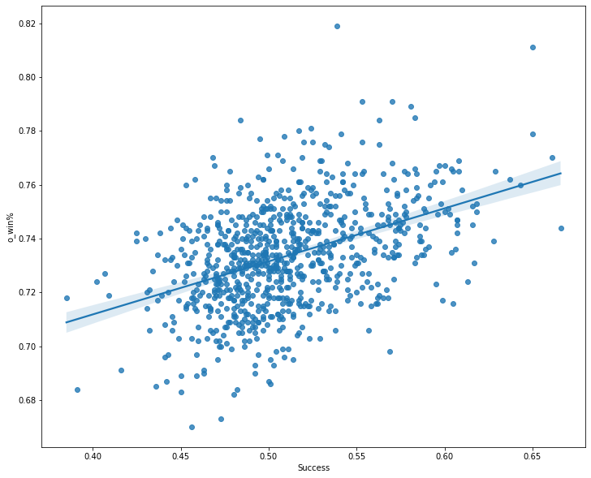

```python
plt.figure(figsize=(12,10))
sns.regplot(x=openings["Success"], y=openings["o_win%"])
plt.show()
```

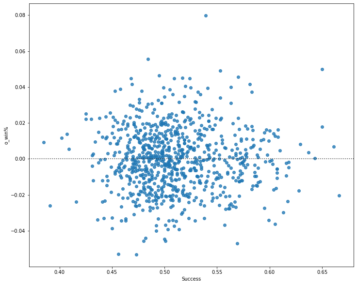

```python
plt.figure(figsize=(12,10))
sns.residplot(x=openings["Success"], y=openings["o_win%"])
plt.show()
```

There is a slight correlation between the success rates of getting opening kills and winning the round off the opening kill.

We will also compare their attempts and their rating, to see if being aggresive will improve their entry fragging rating, as well as their attempts and their impact rating.

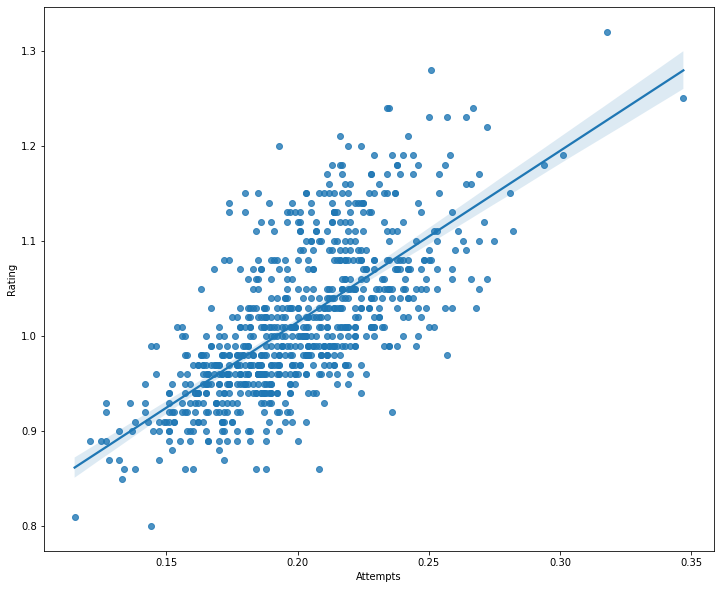

```python
plt.figure(figsize=(12,10))
sns.regplot(x=openings["Attempts"], y=openings["Rating"])
plt.show()
```

There is a strong correlation between attempting more opening duels, and being rated higher as a better entry fragger, as seen by the positive gradient.

To find out if having a very aggresive and sacrificial playstyle with a high opening death per round would mean that if the entry fragger gets the opening kill (5v4) instead of being traded (4v4) it would be much more impactful than entry fraggers who play safer, we will compare the DPR and the o_win%.

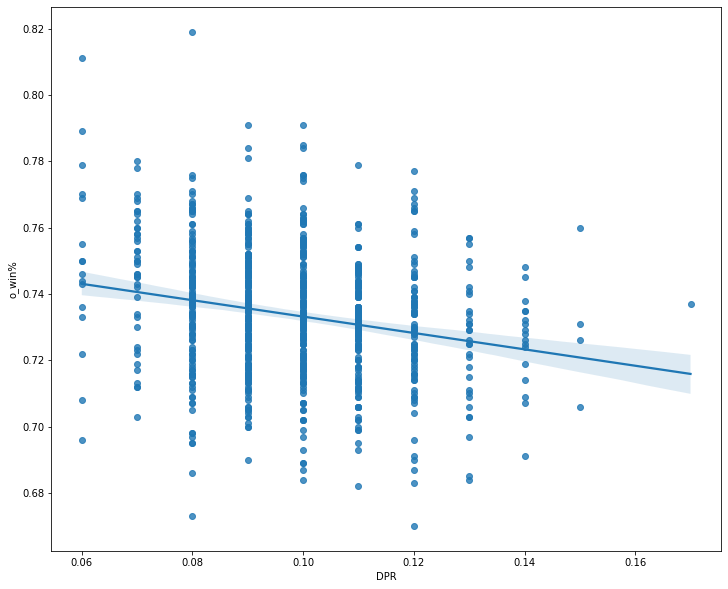

```python
plt.figure(figsize=(12,10))
sns.regplot(x=openings["DPR"], y=openings["o_win%"])
plt.show()
```

There is a slight correlation between the opening deaths per round and the chances of winning the round based off of an opening kill, that as DPR increases o_win% decreases. This means that being the extremely aggressive and reckless entry fragger who sacrifices his own life for the teammate to trade it out is not worth it, since even when they do get the opening kill, their chances of winning the round is not as high as players who play safer with less deaths.

Lastly, we will compare their attempts and their round kills. Does entry-fragging decrease your chances of getting multikills (2k, 3k, 4k or 5k) ?

```python
attempts_round_k = pd.merge(left=openings["Attempts"], left_index=True,
                            right=players.loc[:,"rounds_0k":"rounds_5k"], right_index=True)
attempts_round_k = attempts_round_k.set_index("Attempts", drop=True)
attempts_round_k = attempts_round_k.div(attempts_round_k.sum(axis=1), axis=0)
attempts_round_k.sort_index(inplace=True)
attempts_round_k
```

| Attempts | rounds_0k | rounds_1k | rounds_2k | rounds_3k | rounds_4k | rounds_5k |
| --- | --- | --- | --- | --- | --- | --- |
| 0.115 | 0.557421 | 0.299026 | 0.107789 | 0.028015 | 0.006457 | 0.001291 |
| 0.121 | 0.535987 | 0.300312 | 0.120666 | 0.035208 | 0.007050 | 0.000779 |
| 0.125 | 0.561717 | 0.294148 | 0.109226 | 0.029031 | 0.005213 | 0.000664 |
| 0.127 | 0.521120 | 0.308468 | 0.124825 | 0.037847 | 0.007040 | 0.000699 |
| 0.127 | 0.539873 | 0.299139 | 0.118963 | 0.034818 | 0.006365 | 0.000842 |
| ... | ... | ... | ... | ... | ... | ... |
| 0.282 | 0.527345 | 0.302393 | 0.123870 | 0.037955 | 0.007797 | 0.000641 |
| 0.294 | 0.515283 | 0.292771 | 0.134400 | 0.046085 | 0.010177 | 0.001285 |
| 0.301 | 0.525105 | 0.293271 | 0.128018 | 0.042436 | 0.010075 | 0.001095 |
| 0.318 | 0.494069 | 0.309408 | 0.138226 | 0.046233 | 0.010985 | 0.001078 |
| 0.347 | 0.525195 | 0.300046 | 0.126546 | 0.039701 | 0.007635 | 0.000878 |

817 rows × 6 columns

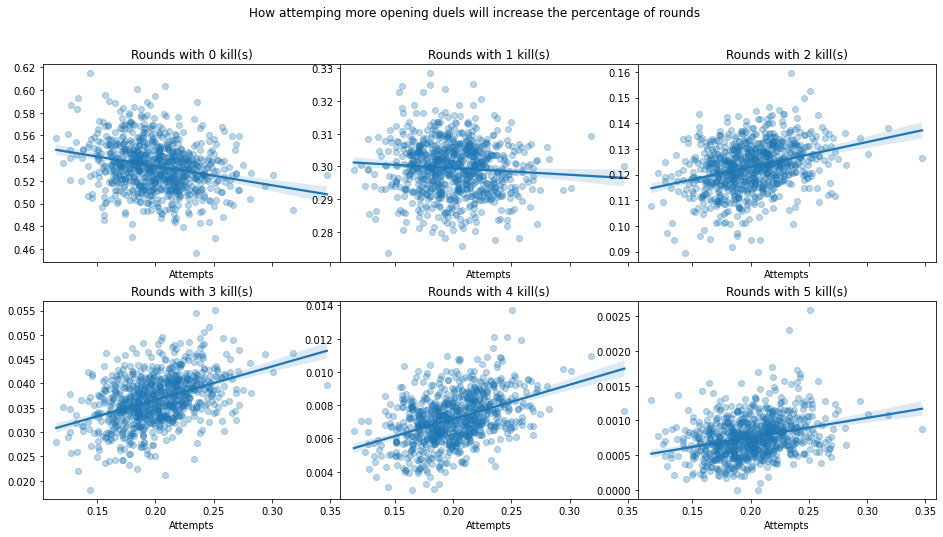

```python
nrow=2
ncol=3

# make a list of all dataframes
fig = plt.figure(figsize=(16,8))
gs = fig.add_gridspec(nrow, ncol, hspace=0.2, wspace=0)
axes = gs.subplots(sharex=True, sharey=False)

# plot counter
count=0
for r in range(nrow):
    for c in range(ncol):
        curr_df = attempts_round_k.iloc[:,count]
        sns.regplot(ax=axes[r,c], x=curr_df.index, y=curr_df.values, scatter_kws={'alpha':0.3})
        axes[r,c].set_title (f'Rounds with {count} kill(s)') #give every subplot a title
        count+=1

plt.suptitle("How attemping more opening duels will increase the percentage of rounds")
plt.show()
```

A trend can be seen where the gradient increases from the scatterplot of 0 kills to 5 kills, which shows how more attempts means a generally higher proportion of rounds with multikills.

### Research Question 2: How does pressure and experience affect performance?

An online match is vastly different from a LAN or Major event. Different players have different reactions to upgrading to playing at a live event in front of a crowd, and whether they will still be the same star that shines online when put on the stage either makes or breaks their careers.

I want to investigate how these different events affect a player's performance, and whether having more experience in playing official matches will make a difference in their consistency on stage.

This will be done by comparing various pools of experience to player's ratings at events, such as how the number of maps of online, LAN, and Major events played affect each aspect's rating.

```python
career["rating increase% online to LAN"] = (career["lan-rating"] - career["online-rating"]) / career["online-rating"] * 100
career["rating increase% LAN to Major"] = (career["majors-rating"] - career["lan-rating"]) / career["lan-rating"] * 100
career = career[~career.index.duplicated()]
career.head()
```

| name | hltv_id | all-rating | online-rating | lan-rating | majors-rating | all-maps | online-maps | lan-maps | majors-maps | rating increase% online to LAN | rating increase% LAN to Major |
| --- | --- | --- | --- | --- | --- | --- | --- | --- | --- | --- | --- |
| ZywOo | 11893 | 1.27 | 1.28 | 1.25 | 1.16 | 1043 | 630 | 413 | 41 | -2.343750 | -7.200000 |
| s1mple | 7998 | 1.25 | 1.24 | 1.26 | 1.21 | 1589 | 850 | 739 | 92 | 1.612903 | -3.968254 |
| sh1ro | 16920 | 1.22 | 1.23 | 1.19 | 1.12 | 886 | 733 | 153 | 15 | -3.252033 | -5.882353 |
| deko | 20113 | 1.21 | 1.21 | 1.14 | NaN | 442 | 435 | 7 | 0 | -5.785124 | NaN |
| saffee | 18835 | 1.20 | 1.22 | 1.10 | 1.05 | 404 | 321 | 83 | 10 | -9.836066 | -4.545455 |

We can find whether a player has better or worse performance on LAN as compared to online matches as a percentage increase/decrease in their rating for the specific events, and similarly for major events. By comparing this against the number of maps played, we can see how the amount of online maps played has prepared them for LAN and Major matches.

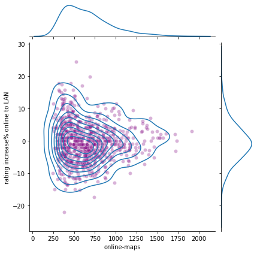

```python
plt.figure(figsize=(12,10))
g = sns.jointplot(x="online-maps", y="rating increase% online to LAN", data=career, kind='kde')
sns.scatterplot(x=career["online-maps"], y=career["rating increase% online to LAN"], alpha=0.3, ax=g.ax_joint, color="Purple")
plt.show()
```

The scatterplot and KDE plot above shows a clear cone shape that is closing in towards a roughly 0% increase (no change) as players have played more online maps.

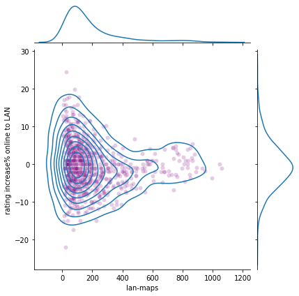

```python
plt.figure(figsize=(12,10))
g = sns.jointplot(x="lan-maps", y="rating increase% online to LAN", data=career, kind='kde')
sns.scatterplot(x=career["lan-maps"], y=career["rating increase% online to LAN"], alpha=0.2, ax=g.ax_joint, color="Purple")
plt.show()
```

This jointplot shows a similar trend of a cone closing in towards 0% change as the number of LAN maps played increases. This cone tightens and becomes thinner faster than the previous cone.

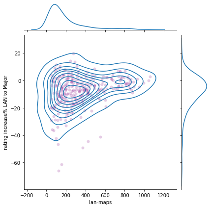

```python
plt.figure(figsize=(12,10))
g = sns.jointplot(x="lan-maps", y="rating increase% LAN to Major", data=career, kind='kde')
sns.scatterplot(x=career["lan-maps"], y=career["rating increase% LAN to Major"], alpha=0.2, ax=g.ax_joint, color="Purple")
plt.show()
```

Similarly, a cone shape can be seen in this graph, however this cone is less symmetrical along the line y=0.

### Research Question 3: How does age impact a player's performance, and their role in a team?

Age is thought to be a pretty big factor in the professional scene of CSGO, as well as in esports in general.

But how true is that? We can find the age distribution of the pro players by drawing a histogram of the ages, showing whether there are just as many old players as there are young guns.

We can find how people of different age groups perform by comparing their age and their ratings, as well as comparing their roles (rifler vs AWPer, entry fragger vs support).

Here we are finding the age distribution of the professional players, as well as how it is correlated to their rating.

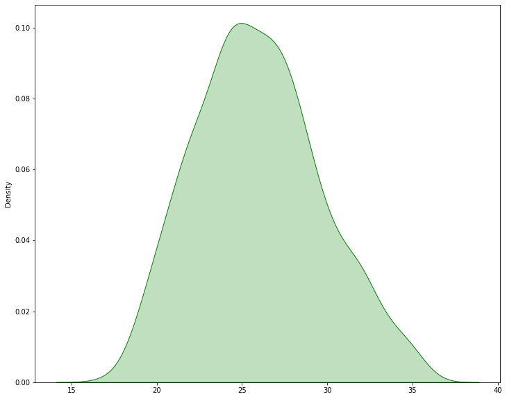

```python
fig,ax = plt.subplots(figsize=(12,10))

sns.kdeplot(players["age"].to_list(), fill=True, ax=ax, color="Green")


plt.show()
```

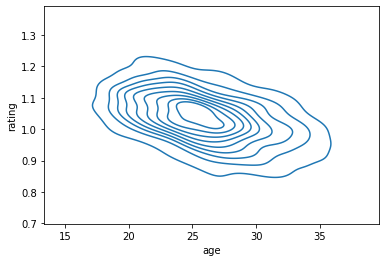

```python
age_vs_rating = players[["age", "rating"]].groupby(["age"]).median()
sns.kdeplot(x=players["age"], y=players["rating"])
```

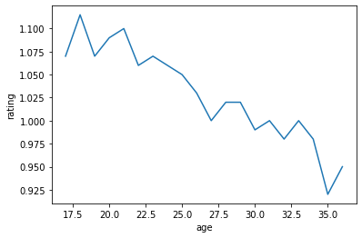

```python
sns.lineplot(x=age_vs_rating.index, y=age_vs_rating["rating"])
```

These graphs compare the distribution of AWPers and Riflers across the ages, so find out if age will affect a player's role in the team.

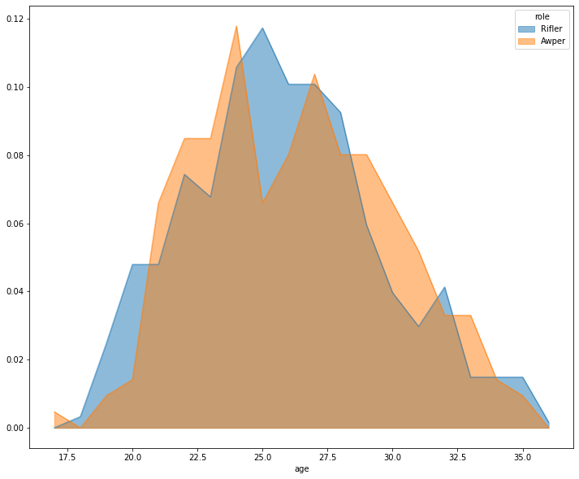

```python
age_role = players[["age", "role"]].value_counts().to_frame(name="count").reset_index()
age_role = pd.pivot_table(age_role, index="age", columns=["role"], values="count")
age_role = age_role.reindex(sorted(age_role.columns)[::-1], axis=1)
age_role = age_role.fillna(0)
age_role = age_role.div(age_role.sum(axis=0), axis=1)

age_role.plot(kind='area', stacked=False, figsize=(12,10))
plt.show()
```

The two areas roughly match, but one could argue that slightly more AWPers are of older age.

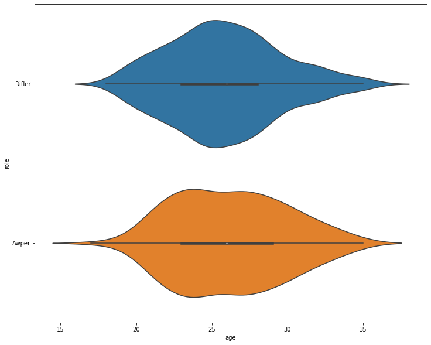

```python
plt.figure(figsize=(12,10))
sns.violinplot(y=players["role"], x=players["age"])
plt.show()
```

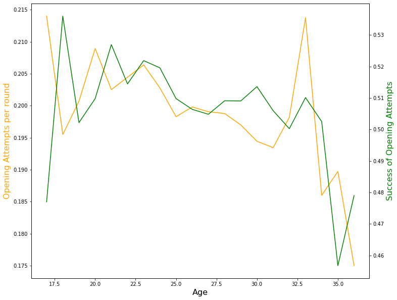

```python
age_opening = pd.merge(left=openings, left_index=True,
                       right=players["age"], right_index=True)
age_opening = age_opening[["age", "Attempts", "Success"]].groupby(["age"]).mean()
age_opening
fig,ax = plt.subplots(figsize=(12,10))
sns.lineplot(x=age_opening.index, y=age_opening["Attempts"], ax=ax, color="Orange")
ax.set_ylabel("Opening Attempts per round", color="Orange", fontsize=16)
ax2 = ax.twinx()
sns.lineplot(x=age_opening.index, y=age_opening["Success"], ax=ax2, color="Green")
ax2.set_ylabel("Success of Opening Attempts", color="Green", fontsize=16)
ax.set_xlabel("Age", fontsize=16)
plt.show()
```

Generally, age does not affect how often a player entry frags in this dataset until around when a player is 33 years old. After 33 years old, the success rate and the attempt rate drops, implying that after 33 years old a player would not be as effective at entry fragging as other younger players.

### Research Question 4: How does different sides affect a role's flashes and pistol rounds?

In CSGO, terrorists (T) attack bombsites (2 bombsites per map) in order to plant the bomb. T wins if they either kill all the counter-terrorists (CT) before the round time runs out, or if they plant the bomb and prevent the CT from defusing the bomb before it explodes.

CT defend bombsites and prevent T from winning by stalling for time so that they cannot plant, eliminating all the T, or by successfully defusing the bomb.

Since the bombsites are placed closer to CT spawn, CTs play a defensive game, waiting for T to push into them most of the time. Whereas T plays a more offensive game, forced to push into CT to win rounds.

The guns and their prices are also slightly different on each side. A notable difference is in the primary rifle. On CT you can buy a M4A4 (or M4A1-S alternatively), which does not guarantee a one headshot kill, while on T you can buy an AK47 for cheaper, with a lower firerate but a one headshot kill.

I want to investigate how playing different sides affect how a rifler, awper, entry fragger or support player's performance in terms of their flash utility and pistol round stats.

```python
flashes = flashes.merge(right=pd.concat([players[["role"]]], axis=1, keys="r"), left_index=True, right_index=True)
flashes = flashes.merge(right=pd.concat([openings[["Attempts", "Rating"]]], axis=1, keys="o"), left_index=True, right_index=True)
flashes.head()
```

|  | CT Maps | CT Rounds | CT Thrown | CT Blinded | CT Opp Flashed | CT Diff | CT FA | CT Success | T Maps | T Rounds | ... | Both Rounds | Both Thrown | Both Blinded | Both Opp Flashed | Both Diff | Both FA | Both Success | r role | o Attempts | o Rating |
| --- | --- | --- | --- | --- | --- | --- | --- | --- | --- | --- | --- | --- | --- | --- | --- | --- | --- | --- | --- | --- | --- |
| kzy | 572 | 7589 | 0.58 | 1.64 | 1.94 | 0.30 | 0.09 | 0.92 | 572 | 7354 | ... | 14943 | 0.78 | 1.39 | 2.24 | 0.85 | 0.10 | 0.80 | Rifler | 0.174 | 0.95 |
| apEX | 1088 | 14491 | 0.42 | 1.91 | 1.44 | -0.46 | 0.06 | 0.91 | 1088 | 14200 | ... | 28691 | 0.57 | 1.60 | 1.59 | -0.01 | 0.07 | 0.76 | Rifler | 0.242 | 1.04 |
| boX | 1275 | 16917 | 0.50 | 1.84 | 1.59 | -0.25 | 0.05 | 0.91 | 1275 | 17066 | ... | 33983 | 0.70 | 1.63 | 1.97 | 0.34 | 0.06 | 0.78 | Rifler | 0.269 | 1.10 |
| Maluk3 | 1007 | 12994 | 0.44 | 2.00 | 1.47 | -0.54 | 0.08 | 0.91 | 1007 | 13047 | ... | 26041 | 0.67 | 1.62 | 1.94 | 0.31 | 0.10 | 0.81 | Awper | 0.214 | 1.13 |
| crisby | 613 | 8150 | 0.56 | 1.41 | 1.90 | 0.49 | 0.07 | 0.90 | 613 | 7897 | ... | 16047 | 0.65 | 1.27 | 1.87 | 0.60 | 0.07 | 0.78 | Rifler | 0.193 | 0.96 |

5 rows × 27 columns

To compare between CT and T side, I will be plotting the same characteristics of each side on the separate axes, then plotting the points on the graph, which will be colored to represent a role. A red line of y=x will be drawn on every graph, representing equal performance on T side and CT side. This will be used to find when players would be performing better on T or on CT.

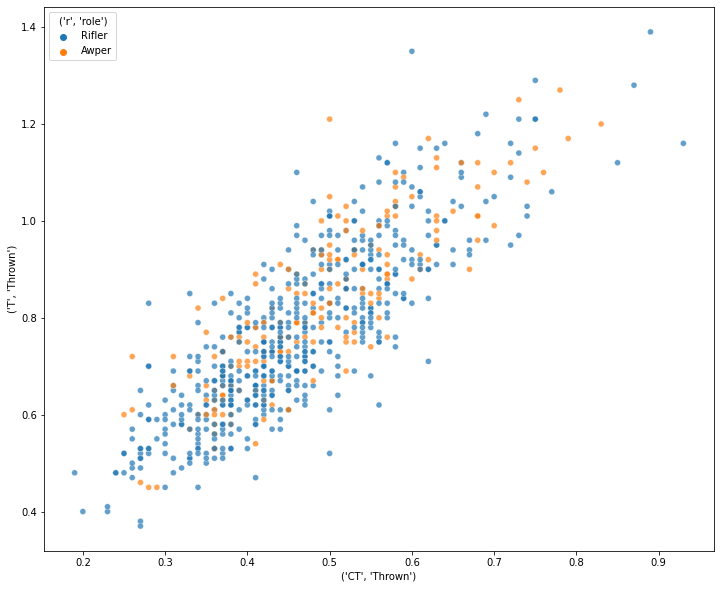

```python
plt.figure(figsize=(12,10))
sns.scatterplot(x=flashes.loc[:, ("CT", "Thrown")], y=flashes[("T", "Thrown")], hue=flashes[("r", "role")], alpha=0.7)
plt.show()
```

As can be seen form this graph, Terrorists throw more flashes than Counter-Terrorists. However, no clear conclusion can be drawn from the differences between the roles.

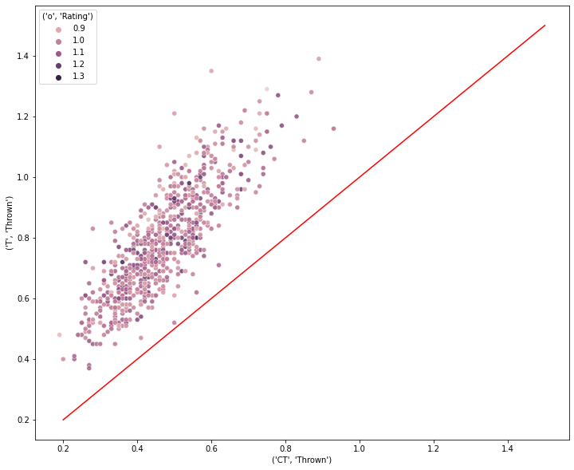

```python
plt.figure(figsize=(12,10))
sns.scatterplot(x=flashes.loc[:, ("CT", "Thrown")], y=flashes[("T", "Thrown")], hue=flashes[("o", "Rating")], alpha=0.9)
plt.plot([0.2, 1.5], [0.2, 1.5], color="Red")
plt.show()
```

Similar to the previous graph, no clear conclusion can be drawn from the differences between the entry fragging rating.

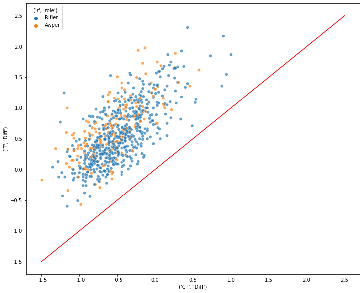

```python
plt.figure(figsize=(12,10))
sns.scatterplot(x=flashes.loc[:, ("CT", "Diff")], y=flashes[("T", "Diff")], hue=flashes[("r", "role")], alpha=0.7)
plt.plot([-1.5, 2.5], [-1.5, 2.5], color="Red")
plt.show()
```

On the T side, players will tend to blind the enemy more often than getting blinded by the enemy as compared to on the CT side. It can be noted that AWPers tend to have a higher Diff value on the T side and a lower value on the CT side.

```python
pistol = pistol.merge(right=pd.concat([players[["role"]]], axis=1, keys="r"), left_index=True, right_index=True)
pistol = pistol.merge(right=pd.concat([openings[["Attempts", "Rating"]]], axis=1, keys="o"), left_index=True, right_index=True)
pistol.head()
```

|  | CT Maps | CT K/D Diff | CT K/D | CT Rating1.0 | T Maps | T K/D Diff | T K/D | T Rating1.0 | Both Maps | Both K/D Diff | Both K/D | Both Rating1.0 | r role | o Attempts | o Rating |
| --- | --- | --- | --- | --- | --- | --- | --- | --- | --- | --- | --- | --- | --- | --- | --- |
| ZywOo | 1043 | 373 | 1.55 | 1.47 | 1043 | 215 | 1.29 | 1.32 | 1043 | 588 | 1.41 | 1.39 | Awper | 0.251 | 1.28 |
| meyern | 466 | 142 | 1.47 | 1.41 | 466 | 5 | 1.01 | 1.03 | 466 | 147 | 1.23 | 1.22 | Rifler | 0.195 | 1.04 |
| deko | 442 | 152 | 1.55 | 1.41 | 442 | 67 | 1.22 | 1.19 | 442 | 219 | 1.38 | 1.30 | Awper | 0.180 | 1.13 |
| b4rtiN | 547 | 184 | 1.52 | 1.40 | 547 | 33 | 1.08 | 1.10 | 547 | 217 | 1.29 | 1.25 | Rifler | 0.181 | 0.99 |
| desi | 430 | 140 | 1.49 | 1.39 | 430 | 6 | 1.02 | 1.09 | 430 | 146 | 1.24 | 1.24 | Rifler | 0.209 | 0.98 |

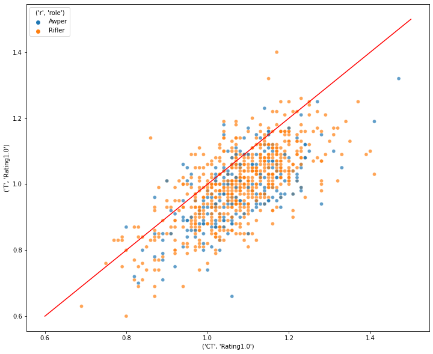

```python
plt.figure(figsize=(12,10))
sns.scatterplot(x=pistol.loc[:, ("CT", "Rating1.0")], y=pistol[("T", "Rating1.0")], hue=pistol[("r", "role")], alpha=0.7)
plt.plot([0.6, 1.5], [0.6, 1.5], color="Red")
plt.show()
```

On the CT side, players tend to have a higher pistol rating than Terrorists. There is no clear correlation between these stats and the player's role.

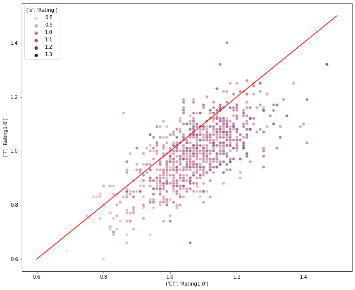

```python
plt.figure(figsize=(12,10))
sns.scatterplot(x=pistol.loc[:, ("CT", "Rating1.0")], y=pistol[("T", "Rating1.0")], hue=pistol[("o", "Rating")], alpha=0.7)
plt.plot([0.6, 1.5], [0.6, 1.5], color="Red")
plt.show()
```

Similar to the previous graph, there is no clear correlation between these stats and the player's entry-fragging rating.

### Research Question 5: How does a player's role affect their performance?

A player could be a rifler or sniper. How do these roles affect their visible performance, in terms of KDA, KAST and such? (represented by their rating) Many casual players and even some pro-players complain that the star fragger, which is usually the sniper/AWPer, gets better statistics due to being set up for kills by the team, which gives the impression that the team is extremely reliant on their star fragger.

I want find out how a player's role will affect their rating, as well as how they get multikills (2k, 3k, 4k or 5kills in a round).

Here, "gun_k" is a dataframe containing the total number of kills by each type of weapon from all the players on the website. I am attempting to find the overall proportion of different types of gun kills, and thus how to delegate the roles based on these statistics.

```python
gun_k = gun_k.sort_values(ascending=False)
gun_k
```

```
rifle_k      7805702
pistol_k     2168574
sniper_k     1741861
smg_k         687143
grenade_k     162272
other_k        53477
dtype: int64
```

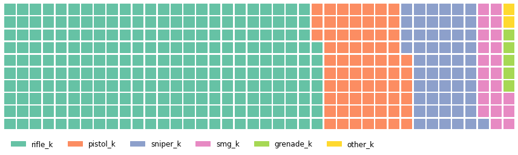

```python
plt.figure(figsize=(12,10))
fig = plt.figure(
    FigureClass=Waffle,
    rows=10,
    columns=40,
    values=gun_k,
    figsize=(12, 8),  # figsize is a parameter of matplotlib.pyplot.figure
    labels = gun_k.index.to_list(),
    legend={
        'loc': 'lower left',
        'bbox_to_anchor': (0, -0.2),
        'ncol': len(gun_k.index.to_list()),
        'framealpha': 0,
        'fontsize': 12
        }
    )

plt.show()
```

It can be seen that rifle kills make up the most of the kills, followed by pistols and then snipers. Pistol kills are so common due to eco rounds where teams save money and only use pistols so that they can have a better economy the following round to have a higher chance of winning that round. Otherwise, a player can either be delegated as a Rifler, or an AWPer (aka Sniper)

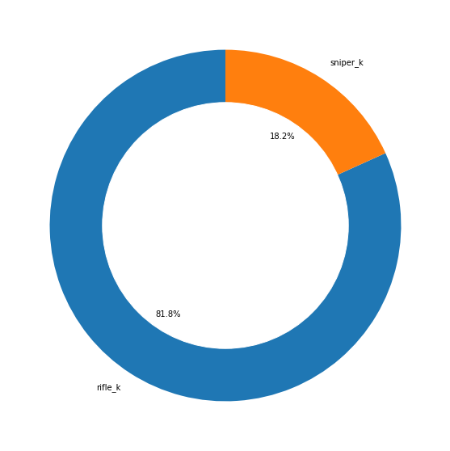

```python
plt.figure(figsize=(12,10))
plt.pie(
    gun_k[["rifle_k", "sniper_k"]],
    labels= gun_k[["rifle_k", "sniper_k"]].index,
    shadow=False,
    colors=sns.color_palette(),
    startangle=90,
    autopct='%1.1f%%',
    )

my_circle=plt.Circle( (0,0), 0.7, color='white')
p=plt.gcf()
p.gca().add_artist(my_circle)
plt.show()
```

Around 1/5 of the total kills are sniper kills, which roughly correlates to how one out of the 5 players usually play the AWP.

Here is a donut-chart showing the proportion of Awpers to Riflers. Their role is delegated based on the previous donut chart, meaning that if a player has a higher sniper to rifle kill ratio than the total ratio from all the players, they are consiered as the awper, and vice versa.

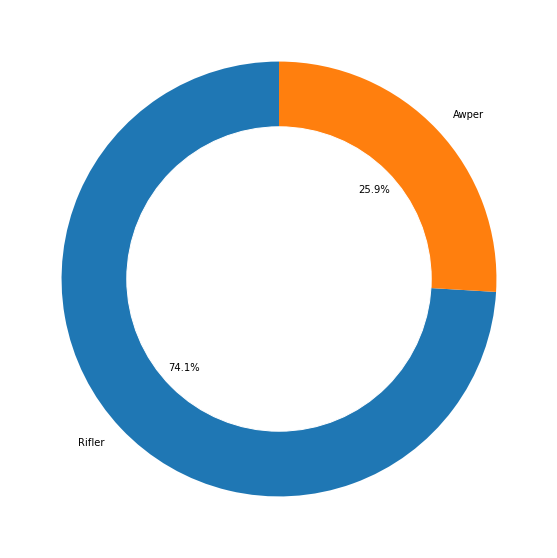

```python
plt.figure(figsize=(12,10))
plt.pie(
    players["role"].value_counts(),
    labels= players["role"].value_counts().index,
    shadow=False,
    colors=sns.color_palette(),
    startangle=90,
    autopct='%1.1f%%',
    )

my_circle=plt.Circle( (0,0), 0.7, color='white')
p=plt.gcf()
p.gca().add_artist(my_circle)

plt.show()
```

Interestingly, around 1/4 of the players would be classified as "AWPers" using this metric. This could be explained by certain players playing hybrid roles, which is a mix of rifling and being the secondary AWPer in the team, as some teams may prefer to have more than one AWPer so that each of the 2 bombsite has one sniper to defend the bombsite

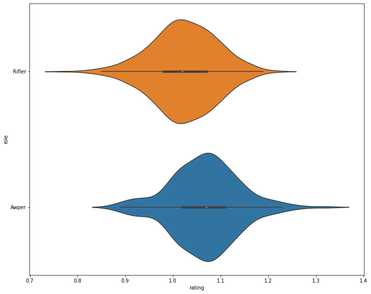

```python
plt.figure(figsize=(12,10))
sns.violinplot(y=players["role"], x=players["rating"], palette=["#ff7f0e", "#1f77b4"])
plt.show()
```

As can be seen from this violinplot, Awpers tend to have a higher rating than Riflers, where it has a higher median as well as a higher inter-quartile range.

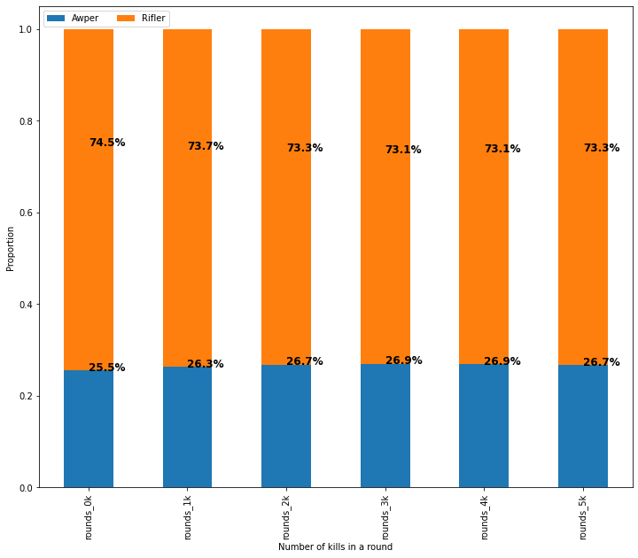

```python
pivot = players.groupby(["role"]).sum().loc[:, "rounds_0k":"rounds_5k"]
pivot = pivot / pivot.sum()
pivot.T.plot(kind='bar', stacked=True, figsize=(12,10))

plt.legend(loc="upper left", ncol=2)
plt.xlabel("Number of kills in a round")
plt.ylabel("Proportion")


for n, x in enumerate([*pivot.T.index.values]):
    for proportion in pivot.T.loc[x]:

        plt.text(x=n,
                 y=proportion,
                 s=f'{np.round(proportion * 100, 1)}%',
                 color="black",
                 fontsize=12,
                 fontweight="bold")

plt.show()
```

There is little correlation of roles to number of kills in a round. However, one may argue that Awpers tend to get slightly more multikills as the percentage increases from 25.5% in rounds with 0 kills to 26.9% in rounds with 4 kills for Awpers.

# Results Findings & Conclusion

For each research question, summarize in 2-3 visualizations which will answer the question. Intrepret the results accordingly and give your observation and conclusion. The visualizations should be well presented (apply what you have learnt in Chapter 9 on data communication). The plots shown here could be an enhanced version of the EDA plots, or presented in another format.

### Research Question 1: What makes a good entry fragger and what does a good entry fragger entail?

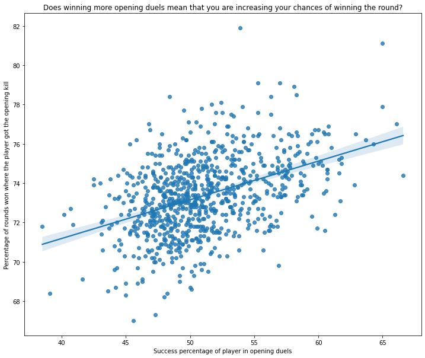

```python
plt.figure(figsize=(12,10))
sns.regplot(x=openings["Success"] * 100, y=openings["o_win%"] * 100)
plt.ylabel("Percentage of rounds won where the player got the opening kill")
plt.xlabel("Success percentage of player in opening duels")
plt.title("Does winning more opening duels mean that you are increasing your chances of winning the round?")
plt.show()
```

There is a slight correlation between the success rates of getting opening kills and winning the round off the opening kill. What this means is that players who tend to win their opening duels are winning duels which are more impactful to the round win. It also means that players who have a low success rate in winning opening duels win duels that do not have as high of an impact on the round as the players with a high success rate.

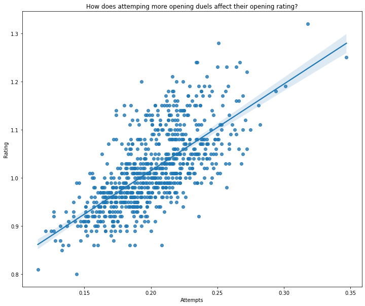

```python
plt.figure(figsize=(12,10))
sns.regplot(x=openings["Attempts"], y=openings["Rating"])
plt.title("How does attemping more opening duels affect their opening rating?")
plt.show()
```

There is a strong correlation between attempting more opening duels, and being rated higher as a better entry fragger, as seen by the positive gradient.

This means that a good entry fragger would be attempting more opening duels. However, there is a possibility that this is an incorrect conclusion as better entry fraggers could be placed in positions to get more opening duels, thus increasing their rating as they attempt more opening duels>

```python
attempts_round_k = pd.merge(left=openings["Attempts"], left_index=True,
                            right=players.loc[:,"rounds_0k":"rounds_5k"], right_index=True)
attempts_round_k = attempts_round_k.set_index("Attempts", drop=True)
attempts_round_k = attempts_round_k.div(attempts_round_k.sum(axis=1), axis=0)
attempts_round_k.sort_index(inplace=True)
attempts_round_k
```

| Attempts | rounds_0k | rounds_1k | rounds_2k | rounds_3k | rounds_4k | rounds_5k |
| --- | --- | --- | --- | --- | --- | --- |
| 0.115 | 0.557421 | 0.299026 | 0.107789 | 0.028015 | 0.006457 | 0.001291 |
| 0.121 | 0.535987 | 0.300312 | 0.120666 | 0.035208 | 0.007050 | 0.000779 |
| 0.125 | 0.561717 | 0.294148 | 0.109226 | 0.029031 | 0.005213 | 0.000664 |
| 0.127 | 0.521120 | 0.308468 | 0.124825 | 0.037847 | 0.007040 | 0.000699 |
| 0.127 | 0.539873 | 0.299139 | 0.118963 | 0.034818 | 0.006365 | 0.000842 |
| ... | ... | ... | ... | ... | ... | ... |
| 0.282 | 0.527345 | 0.302393 | 0.123870 | 0.037955 | 0.007797 | 0.000641 |
| 0.294 | 0.515283 | 0.292771 | 0.134400 | 0.046085 | 0.010177 | 0.001285 |
| 0.301 | 0.525105 | 0.293271 | 0.128018 | 0.042436 | 0.010075 | 0.001095 |
| 0.318 | 0.494069 | 0.309408 | 0.138226 | 0.046233 | 0.010985 | 0.001078 |
| 0.347 | 0.525195 | 0.300046 | 0.126546 | 0.039701 | 0.007635 | 0.000878 |

817 rows × 6 columns

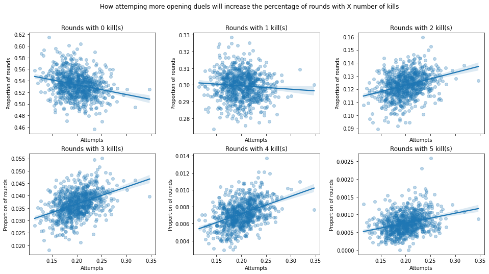

```python
nrow=2
ncol=3

# make a list of all dataframes
fig = plt.figure(figsize=(16,8))
gs = fig.add_gridspec(nrow, ncol, hspace=0.2, wspace=0.3)
axes = gs.subplots(sharex=True, sharey=False)

# plot counter
count=0
for r in range(nrow):
    for c in range(ncol):
        curr_df = attempts_round_k.iloc[:,count]
        sns.regplot(ax=axes[r,c], x=curr_df.index, y=curr_df.values, scatter_kws={'alpha':0.3})
        axes[r,c].set_title (f'Rounds with {count} kill(s)') #give every subplot a title
        axes[r,c].set_ylabel("Proportion of rounds")
        count+=1

plt.suptitle("How attemping more opening duels will increase the percentage of rounds with X number of kills")
plt.show()
```

A trend can be seen where the gradient increases from the scatterplot of 0 kills to 5 kills, which shows how more attempts means a generally higher proportion of rounds with multikills.

This either means that it is easier to string together multikills from getting opening kills, maybe due to a rush of adrenaline after getting the first pick that powers the player to get more kills with more confidence. It could also be that due to the entry fragger getting the first kill most of the time, leaving less enemies for their teammates to kill, whereas the entry fragger is already ahead by 1 kill. Lastly, it could mean that the entry fraggers on the team are the better players designed to start off the round strong by entry fragging, then getting more multikills, but this is a risky strategy as if the star player dies first while entrying, the round will be harder to win afterwards.

In conclusion, a good entry fragger is one that has a high success rate in winning opening duels, as their opening kills are more valuable than the opening kills of players who lose more opening duels due to a higher chance of winning the round. A good entry fragger is also one that attempts opening duels often, thus challenging the opponents and create space for the team. Since a good entry fragger means that they attempt more opening duels more often, they also tend to get more multikills in their matches.

### Research Question 2: How does pressure and experience affect performance?

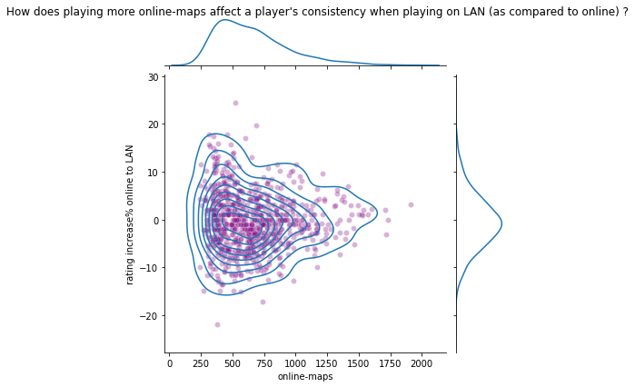

```python
plt.figure(figsize=(12,10))
g = sns.jointplot(x="online-maps", y="rating increase% online to LAN", data=career, kind='kde')
sns.scatterplot(x=career["online-maps"], y=career["rating increase% online to LAN"], alpha=0.3, ax=g.ax_joint, color="Purple")
g.fig.suptitle("How does playing more online-maps affect a player's consistency when playing on LAN (as compared to online) ?")
g.fig.subplots_adjust(top=0.95)
plt.show()
```

The scatterplot and KDE plot above shows a clear cone shape that is closing in towards a roughly 0% increase (no change) as players have played more online maps. This confirms that playing more online maps leads to a more consistent performance at LAN events. This also implies that experience does make a difference in keeping calm and composed, playing as per normal.

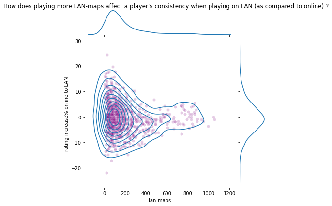

```python
plt.figure(figsize=(12,10))
g = sns.jointplot(x="lan-maps", y="rating increase% online to LAN", data=career, kind='kde')
sns.scatterplot(x=career["lan-maps"], y=career["rating increase% online to LAN"], alpha=0.2, ax=g.ax_joint, color="Purple")
g.fig.suptitle("How does playing more LAN-maps affect a player's consistency when playing on LAN (as compared to online) ?")
g.fig.subplots_adjust(top=0.95)
plt.show()
```

This jointplot shows a similar trend of a cone closing in towards 0% change as the number of LAN maps played increases. This cone tightens and becomes thinner faster than the previous cone, which shows how less LAN maps need to be played to gain more experience and be more consistent in their performance on LAN, implying that LAN experience is more valuable than online match experience.

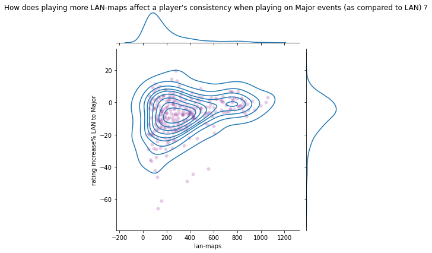

```python
plt.figure(figsize=(12,10))
g = sns.jointplot(x="lan-maps", y="rating increase% LAN to Major", data=career, kind='kde')
sns.scatterplot(x=career["lan-maps"], y=career["rating increase% LAN to Major"], alpha=0.2, ax=g.ax_joint, color="Purple")
g.fig.suptitle("How does playing more LAN-maps affect a player's consistency when playing on Major events (as compared to LAN) ?")
g.fig.subplots_adjust(top=0.95)
plt.show()
```

Similarly, a cone shape can be seen in this graph, however this cone is less symmetrical along the line y=0. Players generally have a large decrease in their performance/rating when moving from LAN to Major, however experience still helps in keeping a consistent performance throughout at near 0% change in rating. It could also be that at Major events, the pressure is much higher, resulting in poorer performances. However, these conclusions could be incorrect due to Majors being only played by the top of the top players, which may cause mediocre players to suffer a much lower rating due to playing against players of the highest calibre. As a result, the change in rating is more so due to the opponents, and not the players themselves.

In conclusion, playing more maps and having more experience is key to maintaining a consistent performance in big events, as shown clearly in the plots above, since playing more maps decreases the fluctuaction of their rating from the other events. Pressure is likely to be a huge factor in performance, one that negatively affects the players as seen in the third figure, where many players had a decrease in rating from LAN rating to Major rating.

### Research Question 3: How does age impact a player's performance, and their role in a team?

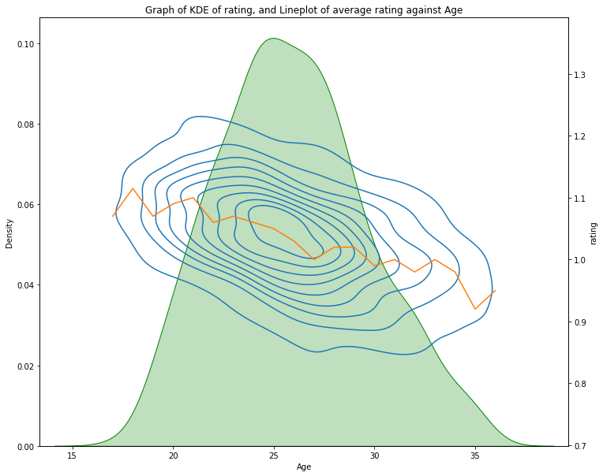

```python
fig,ax = plt.subplots(figsize=(12,10))

sns.kdeplot(players["age"].to_list(), fill=True, ax=ax, color="Green")


age_vs_rating = players[["age", "rating"]].groupby(["age"]).median()
ax2=ax.twinx()
sns.kdeplot(x=players["age"], y=players["rating"], ax=ax2)
sns.lineplot(x=age_vs_rating.index, y=age_vs_rating["rating"], ax=ax2)
ax.set_xlabel("Age")
plt.title("Graph of KDE of rating, and Lineplot of average rating against Age")
plt.show()
```

It shows that the average professional CSGO player is quite young, at that mid-twenties only. It also shows a trend of rating decreasing as age increasing, which suggests that older players do not perform as well as younger players. However, this is based on HLTV's metric to calculate rating, which does not include the contributions of older players' wisdom which they impart onto the team members.

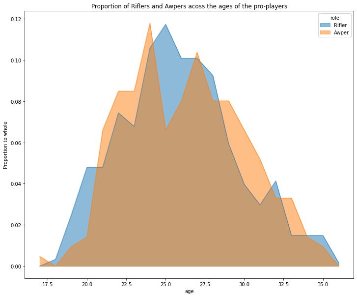

```python
age_role = players[["age", "role"]].value_counts().to_frame(name="count").reset_index()
age_role = pd.pivot_table(age_role, index="age", columns=["role"], values="count")
age_role = age_role.reindex(sorted(age_role.columns)[::-1], axis=1)
age_role = age_role.fillna(0)
age_role = age_role.div(age_role.sum(axis=0), axis=1)

age_role.plot(kind='area', stacked=False, figsize=(12,10))
plt.title("Proportion of Riflers and Awpers acoss the ages of the pro-players")
plt.ylabel("Proportion to whole")
plt.show()
```

The two areas roughly match, but one could argue that slightly more AWPers are of older age. This difference could be due to the fact that older players generally have more experience, and deadly AWPers are ones that have a rich knowledge of the game and their enemies, which allows them to position themselves better to have a higher chance of getting a kill.

In conclusion, an older player would have, in general, a lower HLTV rating than the younger players. This could either be due to them truly being a weaker player, or because their role in a team is more of a support player that sets up the young guns to frag out more or that the impact that they bring to the team is more than what the numbers can show.